# Background & Context

There is a huge demand for used cars in the Indian Market today. As sales of new cars have slowed down, the pre-owned car market has continued to grow over the past years and is larger than the new car market now. Cars4U is a budding tech start-up that aims to find footholes in this market.

In 2018-19, while new car sales were recorded at 3.6 million units, around 4 million second-hand cars were bought and sold. There is a slowdown in new car sales and that could mean that the demand is shifting towards the pre-owned market. In fact, some car sellers replace their old cars with pre-owned cars instead of buying new ones. Unlike new cars, where price and supply are fairly deterministic and managed by OEMs (Original Equipment Manufacturer / except for dealership level discounts which come into play only in the last stage of the customer journey), used cars are very different beasts with huge uncertainty in both pricing and supply. Keeping this in mind, the pricing scheme of these used cars becomes important in order to grow in the market.

As a senior data scientist at Cars4U, you have to come up with a pricing model that can effectively predict the price of used cars and can help the business in devising profitable strategies using differential pricing. For example, if the business knows the market price, it will never sell anything below it.

# Objective

- Explore and visualize the dataset.
- Build a linear regression model to predict the prices of used cars.
- Generate a set of insights and recommendations that will help the business.

**Data Dictionary -**

S.No. : Serial Number

Name : Name of the car which includes Brand name and Model name

Location : The location in which the car is being sold or is available for purchase Cities

Year : Manufacturing year of the car

Kilometers_driven : The total kilometers driven in the car by the previous owner(s) in KM.

Fuel_Type : The type of fuel used by the car. (Petrol, Diesel, Electric, CNG, LPG)

Transmission : The type of transmission used by the car. (Automatic / Manual)

Owner : Type of ownership

Mileage : The standard mileage offered by the car company in kmpl or km/kg

Engine : The displacement volume of the engine in CC.

Power : The maximum power of the engine in bhp.

Seats : The number of seats in the car.

New_Price : The price of a new car of the same model in INR Lakhs.(1 Lakh = 100, 000)

Price : The price of the used car in INR Lakhs (1 Lakh = 100, 000)

```python
import pandas as pd
import numpy as np

import matplotlib.pyplot as plt
import seaborn as sns

pd.set_option("display.max_columns", None)

pd.set_option("display.max_rows", 200)

import statsmodels.stats.api as sms
import warnings
warnings.filterwarnings('ignore')
```

```python
data=pd.read_csv(r'C:\Users\davis\OneDrive\Desktop\Python\Foundations\used_cars_data.csv')
```

```python
data.head(20)
```

|  | S.No. | Name | Location | Year | Kilometers_Driven | Fuel_Type | Transmission | Owner_Type | Mileage | Engine | Power | Seats | New_Price | Price |
| --- | --- | --- | --- | --- | --- | --- | --- | --- | --- | --- | --- | --- | --- | --- |
| 0 | 0 | Maruti Wagon R LXI CNG | Mumbai | 2010 | 72000 | CNG | Manual | First | 26.6 km/kg | 998 CC | 58.16 bhp | 5.0 | NaN | 1.75 |
| 1 | 1 | Hyundai Creta 1.6 CRDi SX Option | Pune | 2015 | 41000 | Diesel | Manual | First | 19.67 kmpl | 1582 CC | 126.2 bhp | 5.0 | NaN | 12.50 |
| 2 | 2 | Honda Jazz V | Chennai | 2011 | 46000 | Petrol | Manual | First | 18.2 kmpl | 1199 CC | 88.7 bhp | 5.0 | 8.61 Lakh | 4.50 |
| 3 | 3 | Maruti Ertiga VDI | Chennai | 2012 | 87000 | Diesel | Manual | First | 20.77 kmpl | 1248 CC | 88.76 bhp | 7.0 | NaN | 6.00 |
| 4 | 4 | Audi A4 New 2.0 TDI Multitronic | Coimbatore | 2013 | 40670 | Diesel | Automatic | Second | 15.2 kmpl | 1968 CC | 140.8 bhp | 5.0 | NaN | 17.74 |
| 5 | 5 | Hyundai EON LPG Era Plus Option | Hyderabad | 2012 | 75000 | LPG | Manual | First | 21.1 km/kg | 814 CC | 55.2 bhp | 5.0 | NaN | 2.35 |
| 6 | 6 | Nissan Micra Diesel XV | Jaipur | 2013 | 86999 | Diesel | Manual | First | 23.08 kmpl | 1461 CC | 63.1 bhp | 5.0 | NaN | 3.50 |
| 7 | 7 | Toyota Innova Crysta 2.8 GX AT 8S | Mumbai | 2016 | 36000 | Diesel | Automatic | First | 11.36 kmpl | 2755 CC | 171.5 bhp | 8.0 | 21 Lakh | 17.50 |
| 8 | 8 | Volkswagen Vento Diesel Comfortline | Pune | 2013 | 64430 | Diesel | Manual | First | 20.54 kmpl | 1598 CC | 103.6 bhp | 5.0 | NaN | 5.20 |
| 9 | 9 | Tata Indica Vista Quadrajet LS | Chennai | 2012 | 65932 | Diesel | Manual | Second | 22.3 kmpl | 1248 CC | 74 bhp | 5.0 | NaN | 1.95 |
| 10 | 10 | Maruti Ciaz Zeta | Kochi | 2018 | 25692 | Petrol | Manual | First | 21.56 kmpl | 1462 CC | 103.25 bhp | 5.0 | 10.65 Lakh | 9.95 |
| 11 | 11 | Honda City 1.5 V AT Sunroof | Kolkata | 2012 | 60000 | Petrol | Automatic | First | 16.8 kmpl | 1497 CC | 116.3 bhp | 5.0 | NaN | 4.49 |
| 12 | 12 | Maruti Swift VDI BSIV | Jaipur | 2015 | 64424 | Diesel | Manual | First | 25.2 kmpl | 1248 CC | 74 bhp | 5.0 | NaN | 5.60 |
| 13 | 13 | Land Rover Range Rover 2.2L Pure | Delhi | 2014 | 72000 | Diesel | Automatic | First | 12.7 kmpl | 2179 CC | 187.7 bhp | 5.0 | NaN | 27.00 |
| 14 | 14 | Land Rover Freelander 2 TD4 SE | Pune | 2012 | 85000 | Diesel | Automatic | Second | 0.0 kmpl | 2179 CC | 115 bhp | 5.0 | NaN | 17.50 |
| 15 | 15 | Mitsubishi Pajero Sport 4X4 | Delhi | 2014 | 110000 | Diesel | Manual | First | 13.5 kmpl | 2477 CC | 175.56 bhp | 7.0 | 32.01 Lakh | 15.00 |
| 16 | 16 | Honda Amaze S i-Dtech | Kochi | 2016 | 58950 | Diesel | Manual | First | 25.8 kmpl | 1498 CC | 98.6 bhp | 5.0 | NaN | 5.40 |
| 17 | 17 | Maruti Swift DDiS VDI | Jaipur | 2017 | 25000 | Diesel | Manual | First | 28.4 kmpl | 1248 CC | 74 bhp | 5.0 | NaN | 5.99 |
| 18 | 18 | Renault Duster 85PS Diesel RxL Plus | Kochi | 2014 | 77469 | Diesel | Manual | First | 20.45 kmpl | 1461 CC | 83.8 bhp | 5.0 | NaN | 6.34 |
| 19 | 19 | Mercedes-Benz New C-Class C 220 CDI BE Avantgare | Bangalore | 2014 | 78500 | Diesel | Automatic | First | 14.84 kmpl | 2143 CC | 167.62 bhp | 5.0 | NaN | 28.00 |

- S.No. is just an index for the data entry. Will drop.
- Car names contain a lot of model information. Further exploration needed with possible processing.
- Mileage, Engine and Power will also need some processing before we are able to explore them. We'll have to extract numerical information from these columns.
- New Price column also needs some processing. This one also contains strings and a lot of missing values.

```python
data.info()
```

```
<class 'pandas.core.frame.DataFrame'>
RangeIndex: 7253 entries, 0 to 7252
Data columns (total 14 columns):
 #   Column             Non-Null Count  Dtype
---  ------             --------------  -----
 0   S.No.              7253 non-null   int64
 1   Name               7253 non-null   object
 2   Location           7253 non-null   object
 3   Year               7253 non-null   int64
 4   Kilometers_Driven  7253 non-null   int64
 5   Fuel_Type          7253 non-null   object
 6   Transmission       7253 non-null   object
 7   Owner_Type         7253 non-null   object
 8   Mileage            7251 non-null   object
 9   Engine             7207 non-null   object
 10  Power              7207 non-null   object
 11  Seats              7200 non-null   float64
 12  New_Price          1006 non-null   object
 13  Price              6019 non-null   float64
dtypes: float64(2), int64(3), object(9)
memory usage: 793.4+ KB
```

`Mileage`, `Engine`, `Power` and `New_Price` are objects when they should be numerical. To be able to get summary statistics for these columns, they must be processed.

# Processing Columns

#### 1. Mileage

Car mileage has two units: kmpl and km/kg.

Each unit in this case, are for different fuel types.

kmpl - kilometers per litre - is used for petrol and diesel engines. km/kg - kilometers per kg - is used for CNG and LPG engines.

`Fuel_type` is also in our data. Let us check if this observations holds true in our data also.

```python
km_per_unit_fuel = []
mileage_unit = []

for observation in data["Mileage"]:
    if isinstance(observation, str):
        if (
            observation.split(" ")[0]
            .replace(".", "", 1)
            .isdigit()  # first element should be numeric
            and " " in observation  # space between numeric and unit
            and (
                observation.split(" ")[1]
                == "kmpl"  # units are limited to "kmpl" and "km/kg"
                or observation.split(" ")[1] == "km/kg"
            )
        ):
            km_per_unit_fuel.append(float(observation.split(" ")[0]))
            mileage_unit.append(observation.split(" ")[1])
        else:
            # To detect if there are any observations in the column that do not follow
            # the expected format [number + ' ' + 'kmpl' or 'km/kg']
            print(
                "The data needs further processing. All values are not similar ",
                observation,
            )
    else:
        # If there are any missing values in the mileage column,
        # we add corresponding missing values to the 2 new columns
        km_per_unit_fuel.append(np.nan)
        mileage_unit.append(np.nan)
```

```python
data["km_per_unit_fuel"] = km_per_unit_fuel
data["mileage_unit"] = mileage_unit


data.head(5)
```

|  | S.No. | Name | Location | Year | Kilometers_Driven | Fuel_Type | Transmission | Owner_Type | Mileage | Engine | Power | Seats | New_Price | Price | km_per_unit_fuel | mileage_unit |
| --- | --- | --- | --- | --- | --- | --- | --- | --- | --- | --- | --- | --- | --- | --- | --- | --- |
| 0 | 0 | Maruti Wagon R LXI CNG | Mumbai | 2010 | 72000 | CNG | Manual | First | 26.6 km/kg | 998 CC | 58.16 bhp | 5.0 | NaN | 1.75 | 26.60 | km/kg |
| 1 | 1 | Hyundai Creta 1.6 CRDi SX Option | Pune | 2015 | 41000 | Diesel | Manual | First | 19.67 kmpl | 1582 CC | 126.2 bhp | 5.0 | NaN | 12.50 | 19.67 | kmpl |
| 2 | 2 | Honda Jazz V | Chennai | 2011 | 46000 | Petrol | Manual | First | 18.2 kmpl | 1199 CC | 88.7 bhp | 5.0 | 8.61 Lakh | 4.50 | 18.20 | kmpl |
| 3 | 3 | Maruti Ertiga VDI | Chennai | 2012 | 87000 | Diesel | Manual | First | 20.77 kmpl | 1248 CC | 88.76 bhp | 7.0 | NaN | 6.00 | 20.77 | kmpl |
| 4 | 4 | Audi A4 New 2.0 TDI Multitronic | Coimbatore | 2013 | 40670 | Diesel | Automatic | Second | 15.2 kmpl | 1968 CC | 140.8 bhp | 5.0 | NaN | 17.74 | 15.20 | kmpl |

```python
data.groupby(by=["Fuel_Type", "mileage_unit"]).size()
```

```
Fuel_Type  mileage_unit
CNG        km/kg             62
Diesel     kmpl            3852
LPG        km/kg             12
Petrol     kmpl            3325
dtype: int64
```

- km/kg is for CNG/LPG engines and kmpl is for Petrol and Diesel engines.

#### 2. Engine

The data dictionary suggests that `Engine` indicates the displacement volume of the engine in CC. Make sure that all the observations follow the same format and create a new numeric column from this column.

Regrex to make all the neccesary checks.

```python
import re


engine_num = []


regex_engine = "^\d+(\.\d+)? CC$"

for observation in data["Engine"]:
    if isinstance(observation, str):
        if re.match(regex_engine, observation):
            engine_num.append(float(observation.split(" ")[0]))
        else:

            print(
                "The data needs furthur processing. All values are not similar ",
                observation,
            )
    else:

        engine_num.append(np.nan)
```

```python
# No print output from the function above. The values are all in the same format - [numeric + " " + "CC"] OR NaNs
# Add the new column to the data

data["engine_num"] = engine_num

# Checking the new dataframe
data.head(5)
```

|  | S.No. | Name | Location | Year | Kilometers_Driven | Fuel_Type | Transmission | Owner_Type | Mileage | Engine | Power | Seats | New_Price | Price | km_per_unit_fuel | mileage_unit | engine_num |
| --- | --- | --- | --- | --- | --- | --- | --- | --- | --- | --- | --- | --- | --- | --- | --- | --- | --- |
| 0 | 0 | Maruti Wagon R LXI CNG | Mumbai | 2010 | 72000 | CNG | Manual | First | 26.6 km/kg | 998 CC | 58.16 bhp | 5.0 | NaN | 1.75 | 26.60 | km/kg | 998.0 |
| 1 | 1 | Hyundai Creta 1.6 CRDi SX Option | Pune | 2015 | 41000 | Diesel | Manual | First | 19.67 kmpl | 1582 CC | 126.2 bhp | 5.0 | NaN | 12.50 | 19.67 | kmpl | 1582.0 |
| 2 | 2 | Honda Jazz V | Chennai | 2011 | 46000 | Petrol | Manual | First | 18.2 kmpl | 1199 CC | 88.7 bhp | 5.0 | 8.61 Lakh | 4.50 | 18.20 | kmpl | 1199.0 |
| 3 | 3 | Maruti Ertiga VDI | Chennai | 2012 | 87000 | Diesel | Manual | First | 20.77 kmpl | 1248 CC | 88.76 bhp | 7.0 | NaN | 6.00 | 20.77 | kmpl | 1248.0 |
| 4 | 4 | Audi A4 New 2.0 TDI Multitronic | Coimbatore | 2013 | 40670 | Diesel | Automatic | Second | 15.2 kmpl | 1968 CC | 140.8 bhp | 5.0 | NaN | 17.74 | 15.20 | kmpl | 1968.0 |

#### 3. Power

The data dictionary suggests that `Power` indicates the maximum power of the engine in bhp. Make sure that all the observations follow the same format and create a new numeric column from this column.

```python
power_num = []


regex_power = "^\d+(\.\d+)? bhp$"

for observation in data["Power"]:
    if isinstance(observation, str):
        if re.match(regex_power, observation):
            power_num.append(float(observation.split(" ")[0]))
        else:


            print(
                "The data needs furthur processing. All values are not similar ",
                observation,
            )
    else:

        power_num.append(np.nan)
```

[output not shown]

[output cut: 74 more lines]

[output not shown]

Some Null values in power column exist as 'null bhp' string. Replace these with NaNs.

```python
power_num = []

for observation in data["Power"]:
    if isinstance(observation, str):
        if re.match(regex_power, observation):
            power_num.append(float(observation.split(" ")[0]))
        else:
            power_num.append(np.nan)
    else:

        power_num.append(np.nan)


data["power_num"] = power_num


data.head(10)
```

|  | S.No. | Name | Location | Year | Kilometers_Driven | Fuel_Type | Transmission | Owner_Type | Mileage | Engine | Power | Seats | New_Price | Price | km_per_unit_fuel | mileage_unit | engine_num | power_num |
| --- | --- | --- | --- | --- | --- | --- | --- | --- | --- | --- | --- | --- | --- | --- | --- | --- | --- | --- |
| 0 | 0 | Maruti Wagon R LXI CNG | Mumbai | 2010 | 72000 | CNG | Manual | First | 26.6 km/kg | 998 CC | 58.16 bhp | 5.0 | NaN | 1.75 | 26.60 | km/kg | 998.0 | 58.16 |
| 1 | 1 | Hyundai Creta 1.6 CRDi SX Option | Pune | 2015 | 41000 | Diesel | Manual | First | 19.67 kmpl | 1582 CC | 126.2 bhp | 5.0 | NaN | 12.50 | 19.67 | kmpl | 1582.0 | 126.20 |
| 2 | 2 | Honda Jazz V | Chennai | 2011 | 46000 | Petrol | Manual | First | 18.2 kmpl | 1199 CC | 88.7 bhp | 5.0 | 8.61 Lakh | 4.50 | 18.20 | kmpl | 1199.0 | 88.70 |
| 3 | 3 | Maruti Ertiga VDI | Chennai | 2012 | 87000 | Diesel | Manual | First | 20.77 kmpl | 1248 CC | 88.76 bhp | 7.0 | NaN | 6.00 | 20.77 | kmpl | 1248.0 | 88.76 |
| 4 | 4 | Audi A4 New 2.0 TDI Multitronic | Coimbatore | 2013 | 40670 | Diesel | Automatic | Second | 15.2 kmpl | 1968 CC | 140.8 bhp | 5.0 | NaN | 17.74 | 15.20 | kmpl | 1968.0 | 140.80 |
| 5 | 5 | Hyundai EON LPG Era Plus Option | Hyderabad | 2012 | 75000 | LPG | Manual | First | 21.1 km/kg | 814 CC | 55.2 bhp | 5.0 | NaN | 2.35 | 21.10 | km/kg | 814.0 | 55.20 |
| 6 | 6 | Nissan Micra Diesel XV | Jaipur | 2013 | 86999 | Diesel | Manual | First | 23.08 kmpl | 1461 CC | 63.1 bhp | 5.0 | NaN | 3.50 | 23.08 | kmpl | 1461.0 | 63.10 |
| 7 | 7 | Toyota Innova Crysta 2.8 GX AT 8S | Mumbai | 2016 | 36000 | Diesel | Automatic | First | 11.36 kmpl | 2755 CC | 171.5 bhp | 8.0 | 21 Lakh | 17.50 | 11.36 | kmpl | 2755.0 | 171.50 |
| 8 | 8 | Volkswagen Vento Diesel Comfortline | Pune | 2013 | 64430 | Diesel | Manual | First | 20.54 kmpl | 1598 CC | 103.6 bhp | 5.0 | NaN | 5.20 | 20.54 | kmpl | 1598.0 | 103.60 |
| 9 | 9 | Tata Indica Vista Quadrajet LS | Chennai | 2012 | 65932 | Diesel | Manual | Second | 22.3 kmpl | 1248 CC | 74 bhp | 5.0 | NaN | 1.95 | 22.30 | kmpl | 1248.0 | 74.00 |

#### 4. New_Price

We know that `New_Price` is the price of a new car of the same model in INR Lakhs.(1 Lakh = 100,000)

This column has a lot of missing values. Impute the missing values later. Extract the numeric values from this column now.

```python
new_price_num = []


regex_power = "^\d+(\.\d+)? Lakh$"

for observation in data["New_Price"]:
    if isinstance(observation, str):
        if re.match(regex_power, observation):
            new_price_num.append(float(observation.split(" ")[0]))
        else:


            print(
                "The data needs furthur processing. All values are not similar ",
                observation,
            )
    else:

        new_price_num.append(np.nan)
```

```
The data needs furthur processing. All values are not similar  1.28 Cr
The data needs furthur processing. All values are not similar  1.04 Cr
The data needs furthur processing. All values are not similar  1 Cr
The data needs furthur processing. All values are not similar  1.04 Cr
The data needs furthur processing. All values are not similar  1.39 Cr
The data needs furthur processing. All values are not similar  1.02 Cr
The data needs furthur processing. All values are not similar  1.4 Cr
The data needs furthur processing. All values are not similar  1.06 Cr
The data needs furthur processing. All values are not similar  1.27 Cr
The data needs furthur processing. All values are not similar  1.13 Cr
The data needs furthur processing. All values are not similar  1.36 Cr
The data needs furthur processing. All values are not similar  1.66 Cr
The data needs furthur processing. All values are not similar  1.6 Cr
The data needs furthur processing. All values are not similar  1.28 Cr
The data needs furthur processing. All values are not similar  2.3 Cr
The data needs furthur processing. All values are not similar  1.71 Cr
The data needs furthur processing. All values are not similar  1.39 Cr
The data needs furthur processing. All values are not similar  1.58 Cr
The data needs furthur processing. All values are not similar  3.75 Cr
The data needs furthur processing. All values are not similar  1.06 Cr
```

Not all values are in Lakhs. There are a few observations that are in Crores.

Convert all values to lakhs. 1 Cr = 100 Lakhs

```python
new_price_num = []

for observation in data["New_Price"]:
    if isinstance(observation, str):
        if re.match(regex_power, observation):
            new_price_num.append(float(observation.split(" ")[0]))
        else:

            new_price_num.append(float(observation.split(" ")[0]) * 100)
    else:

        new_price_num.append(np.nan)


data["new_price_num"] = new_price_num


data.head(5)
```

|  | S.No. | Name | Location | Year | Kilometers_Driven | Fuel_Type | Transmission | Owner_Type | Mileage | Engine | Power | Seats | New_Price | Price | km_per_unit_fuel | mileage_unit | engine_num | power_num | new_price_num |
| --- | --- | --- | --- | --- | --- | --- | --- | --- | --- | --- | --- | --- | --- | --- | --- | --- | --- | --- | --- |
| 0 | 0 | Maruti Wagon R LXI CNG | Mumbai | 2010 | 72000 | CNG | Manual | First | 26.6 km/kg | 998 CC | 58.16 bhp | 5.0 | NaN | 1.75 | 26.60 | km/kg | 998.0 | 58.16 | NaN |
| 1 | 1 | Hyundai Creta 1.6 CRDi SX Option | Pune | 2015 | 41000 | Diesel | Manual | First | 19.67 kmpl | 1582 CC | 126.2 bhp | 5.0 | NaN | 12.50 | 19.67 | kmpl | 1582.0 | 126.20 | NaN |
| 2 | 2 | Honda Jazz V | Chennai | 2011 | 46000 | Petrol | Manual | First | 18.2 kmpl | 1199 CC | 88.7 bhp | 5.0 | 8.61 Lakh | 4.50 | 18.20 | kmpl | 1199.0 | 88.70 | 8.61 |
| 3 | 3 | Maruti Ertiga VDI | Chennai | 2012 | 87000 | Diesel | Manual | First | 20.77 kmpl | 1248 CC | 88.76 bhp | 7.0 | NaN | 6.00 | 20.77 | kmpl | 1248.0 | 88.76 | NaN |
| 4 | 4 | Audi A4 New 2.0 TDI Multitronic | Coimbatore | 2013 | 40670 | Diesel | Automatic | Second | 15.2 kmpl | 1968 CC | 140.8 bhp | 5.0 | NaN | 17.74 | 15.20 | kmpl | 1968.0 | 140.80 | NaN |

# Feature Engineering

The `Name` column in the current format might not be very useful. Since the name contains both the brand name and the model name of the vehicle, the column would have too many unique values to be useful in prediction.

```python
data["Name"].nunique()
```

```
2041
```

With 2041 unique names, car names are not going to be great predictors of the price in our current data.

#### 1. Car Brand Name

```python
data["Brand"] = data["Name"].apply(lambda x: x.split(" ")[0].lower())


data["Brand"].value_counts()
```

```
maruti           1444
hyundai          1340
honda             743
toyota            507
mercedes-benz     380
volkswagen        374
ford              351
mahindra          331
bmw               312
audi              285
tata              228
skoda             202
renault           170
chevrolet         151
nissan            117
land               67
jaguar             48
fiat               38
mitsubishi         36
mini               31
volvo              28
porsche            19
jeep               19
datsun             17
isuzu               5
force               3
bentley             2
ambassador          1
lamborghini         1
opelcorsa           1
smart               1
hindustan           1
Name: Brand, dtype: int64
```

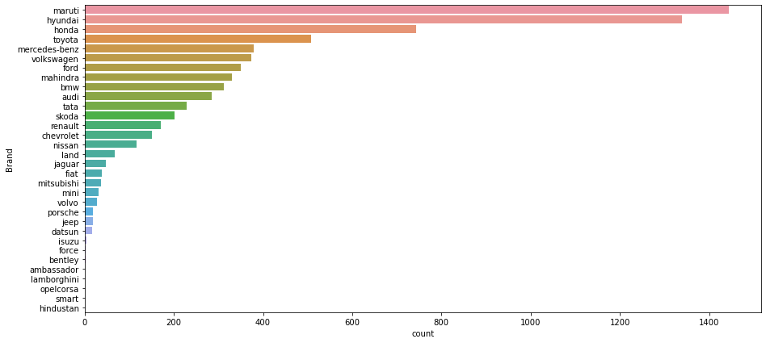

```python
plt.figure(figsize=(15, 7))
sns.countplot(y="Brand", data=data, order=data["Brand"].value_counts().index)
```

#### 2. Car Model Name

```python
data["Model"] = data["Name"].apply(lambda x: x.split(" ")[1].lower())

data["Model"].value_counts()
```

```
swift          418
city           318
i20            303
innova         203
verna          200
              ...
mustang          1
prius            1
land             1
continental      1
countryman       1
Name: Model, Length: 218, dtype: int64
```

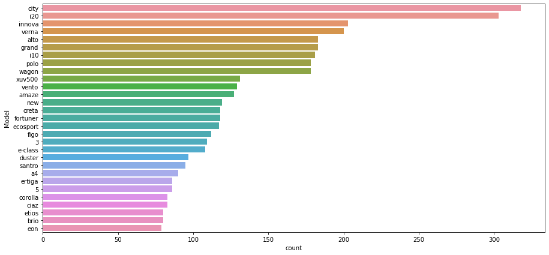

```python
plt.figure(figsize=(15, 7))
sns.countplot(y="Model", data=data, order=data["Model"].value_counts().index[1:30])
```

The charts show our dataset contains used cars from luxury as well as cheaper brands.

We can create a new variable using this information. Bin all our cars in 3 categories -

1. Budget Friendly
2. Mid Range
3. Luxury Cars

#### 3. Car_category

```python
data.groupby(["Brand"])["Price"].mean().sort_values(ascending=False)
```

```
Brand
lamborghini      120.000000
bentley           59.000000
porsche           48.348333
land              39.259500
jaguar            37.632250
mini              26.896923
mercedes-benz     26.809874
audi              25.537712
bmw               25.243146
volvo             18.802857
jeep              18.718667
isuzu             14.696667
toyota            11.580024
mitsubishi        11.058889
force              9.333333
mahindra           8.045919
skoda              7.559075
ford               6.889400
renault            5.799034
honda              5.411743
hyundai            5.343433
volkswagen         5.307270
nissan             4.738352
maruti             4.517267
tata               3.562849
fiat               3.269286
datsun             3.049231
chevrolet          3.044463
smart              3.000000
ambassador         1.350000
hindustan               NaN
opelcorsa               NaN
Name: Price, dtype: float64
```

Car categories in decending order most to least expensive. Missing data indicated.

# Exploratory Data Analysis

```python
data.describe().T
```

|  | count | mean | std | min | 25% | 50% | 75% | max |
| --- | --- | --- | --- | --- | --- | --- | --- | --- |
| S.No. | 7253.0 | 3626.000000 | 2093.905084 | 0.00 | 1813.000 | 3626.00 | 5439.0000 | 7252.00 |
| Year | 7253.0 | 2013.365366 | 3.254421 | 1996.00 | 2011.000 | 2014.00 | 2016.0000 | 2019.00 |
| Kilometers_Driven | 7253.0 | 58699.063146 | 84427.720583 | 171.00 | 34000.000 | 53416.00 | 73000.0000 | 6500000.00 |
| Seats | 7200.0 | 5.279722 | 0.811660 | 0.00 | 5.000 | 5.00 | 5.0000 | 10.00 |
| Price | 6019.0 | 9.479468 | 11.187917 | 0.44 | 3.500 | 5.64 | 9.9500 | 160.00 |
| km_per_unit_fuel | 7251.0 | 18.141580 | 4.562197 | 0.00 | 15.170 | 18.16 | 21.1000 | 33.54 |
| engine_num | 7207.0 | 1616.573470 | 595.285137 | 72.00 | 1198.000 | 1493.00 | 1968.0000 | 5998.00 |
| power_num | 7078.0 | 112.765214 | 53.493553 | 34.20 | 75.000 | 94.00 | 138.1000 | 616.00 |
| new_price_num | 1006.0 | 22.779692 | 27.759344 | 3.91 | 7.885 | 11.57 | 26.0425 | 375.00 |

1. S.No. Drop data.
2. Kilometers_Driven values have an incredibly high range. Possible outliers.
3. Minimum and maximum number of seats need exploring. The data shows cars to have an average of 5 seats.
4. We have used cars being sold at less than a lakh rupees and as high as 160 lakh. Possibly have to drop some of these outliers to build a robust model.
5. Min Mileage being 0 for used cars is a problem outlier.
6. Engine and Power mean and median values are not very different.
7. New price range seems right.

```python
data.sort_values(by=["Kilometers_Driven"], ascending=False).head(10)
```

|  | S.No. | Name | Location | Year | Kilometers_Driven | Fuel_Type | Transmission | Owner_Type | Mileage | Engine | Power | Seats | New_Price | Price | km_per_unit_fuel | mileage_unit | engine_num | power_num | new_price_num | Brand | Model |
| --- | --- | --- | --- | --- | --- | --- | --- | --- | --- | --- | --- | --- | --- | --- | --- | --- | --- | --- | --- | --- | --- |
| 2328 | 2328 | BMW X5 xDrive 30d M Sport | Chennai | 2017 | 6500000 | Diesel | Automatic | First | 15.97 kmpl | 2993 CC | 258 bhp | 5.0 | NaN | 65.00 | 15.97 | kmpl | 2993.0 | 258.00 | NaN | bmw | x5 |
| 340 | 340 | Skoda Octavia Ambition Plus 2.0 TDI AT | Kolkata | 2013 | 775000 | Diesel | Automatic | First | 19.3 kmpl | 1968 CC | 141 bhp | 5.0 | NaN | 7.50 | 19.30 | kmpl | 1968.0 | 141.00 | NaN | skoda | octavia |
| 1860 | 1860 | Volkswagen Vento Diesel Highline | Chennai | 2013 | 720000 | Diesel | Manual | First | 20.54 kmpl | 1598 CC | 103.6 bhp | 5.0 | NaN | 5.90 | 20.54 | kmpl | 1598.0 | 103.60 | NaN | volkswagen | vento |
| 358 | 358 | Hyundai i10 Magna 1.2 | Chennai | 2009 | 620000 | Petrol | Manual | First | 20.36 kmpl | 1197 CC | 78.9 bhp | 5.0 | NaN | 2.70 | 20.36 | kmpl | 1197.0 | 78.90 | NaN | hyundai | i10 |
| 2823 | 2823 | Volkswagen Jetta 2013-2015 2.0L TDI Highline AT | Chennai | 2015 | 480000 | Diesel | Automatic | First | 16.96 kmpl | 1968 CC | 138.03 bhp | 5.0 | NaN | 13.00 | 16.96 | kmpl | 1968.0 | 138.03 | NaN | volkswagen | jetta |
| 3092 | 3092 | Honda City i VTEC SV | Kolkata | 2015 | 480000 | Petrol | Manual | First | 17.4 kmpl | 1497 CC | 117.3 bhp | 5.0 | NaN | 5.00 | 17.40 | kmpl | 1497.0 | 117.30 | NaN | honda | city |
| 4491 | 4491 | Hyundai i20 Magna Optional 1.2 | Bangalore | 2013 | 445000 | Petrol | Manual | First | 18.5 kmpl | 1197 CC | 82.9 bhp | 5.0 | NaN | 4.45 | 18.50 | kmpl | 1197.0 | 82.90 | NaN | hyundai | i20 |
| 6921 | 6921 | Maruti Swift Dzire Tour LDI | Jaipur | 2012 | 350000 | Diesel | Manual | First | 23.4 kmpl | 1248 CC | 74 bhp | 5.0 | NaN | NaN | 23.40 | kmpl | 1248.0 | 74.00 | NaN | maruti | swift |
| 3649 | 3649 | Tata Indigo LS | Jaipur | 2008 | 300000 | Diesel | Manual | First | 17.0 kmpl | 1405 CC | 70 bhp | 5.0 | NaN | 1.00 | 17.00 | kmpl | 1405.0 | 70.00 | NaN | tata | indigo |
| 1528 | 1528 | Toyota Innova 2.5 G (Diesel) 8 Seater BS IV | Hyderabad | 2005 | 299322 | Diesel | Manual | First | 12.8 kmpl | 2494 CC | 102 bhp | 8.0 | NaN | 4.00 | 12.80 | kmpl | 2494.0 | 102.00 | NaN | toyota | innova |

It looks like the first row here is a data entry error. 2017 year model having been driven 6500000 kms is not likely.

```python
data.sort_values(by=["Kilometers_Driven"], ascending=True).head(10)
```

|  | S.No. | Name | Location | Year | Kilometers_Driven | Fuel_Type | Transmission | Owner_Type | Mileage | Engine | Power | Seats | New_Price | Price | km_per_unit_fuel | mileage_unit | engine_num | power_num | new_price_num | Brand | Model |
| --- | --- | --- | --- | --- | --- | --- | --- | --- | --- | --- | --- | --- | --- | --- | --- | --- | --- | --- | --- | --- | --- |
| 1361 | 1361 | Maruti Alto 800 2016-2019 VXI | Mumbai | 2019 | 171 | Petrol | Manual | First | 24.7 kmpl | 796 CC | 47.3 bhp | 5.0 | NaN | 3.60 | 24.70 | kmpl | 796.0 | 47.30 | NaN | maruti | alto |
| 5606 | 5606 | Maruti Wagon R ZXI AMT 1.2 | Mumbai | 2019 | 600 | Petrol | Automatic | First | 21.5 kmpl | 1197 CC | 81.80 bhp | 5.0 | 6.8 Lakh | 6.25 | 21.50 | kmpl | 1197.0 | 81.80 | 6.80 | maruti | wagon |
| 1198 | 1198 | Volkswagen Polo 1.0 MPI Trendline | Hyderabad | 2019 | 1000 | Petrol | Manual | First | 18.78 kmpl | 999 CC | 75 bhp | 5.0 | 6.74 Lakh | 5.68 | 18.78 | kmpl | 999.0 | 75.00 | 6.74 | volkswagen | polo |
| 5941 | 5941 | Renault KWID RXL | Pune | 2018 | 1000 | Petrol | Manual | First | 25.17 kmpl | 799 CC | 53.3 bhp | 5.0 | 4.45 Lakh | 3.40 | 25.17 | kmpl | 799.0 | 53.30 | 4.45 | renault | kwid |
| 6201 | 6201 | Maruti Alto LXI | Kolkata | 2019 | 1000 | Petrol | Manual | First | 24.7 kmpl | 796 CC | 47.3 bhp | 5.0 | 3.99 Lakh | NaN | 24.70 | kmpl | 796.0 | 47.30 | 3.99 | maruti | alto |
| 1161 | 1161 | Tata Tigor 1.2 Revotron XTA | Ahmedabad | 2018 | 1000 | Petrol | Automatic | First | 20.3 kmpl | 1199 CC | 84 bhp | 5.0 | NaN | 6.85 | 20.30 | kmpl | 1199.0 | 84.00 | NaN | tata | tigor |
| 1598 | 1598 | Tata Xenon XT EX 4X2 | Jaipur | 2017 | 1000 | Diesel | Manual | First | 13.49 kmpl | 2179 CC | 138.03 bhp | 5.0 | NaN | 7.50 | 13.49 | kmpl | 2179.0 | 138.03 | NaN | tata | xenon |
| 173 | 173 | Hyundai Grand i10 1.2 Kappa Asta | Kolkata | 2019 | 1000 | Petrol | Manual | First | 18.9 kmpl | 1197 CC | 81.86 bhp | 5.0 | 7.39 Lakh | 6.50 | 18.90 | kmpl | 1197.0 | 81.86 | 7.39 | hyundai | grand |
| 1242 | 1242 | Jaguar XE 2.0L Diesel Prestige | Delhi | 2018 | 1000 | Diesel | Automatic | First | 13.6 kmpl | 1999 CC | 177 bhp | 5.0 | 52.77 Lakh | 40.00 | 13.60 | kmpl | 1999.0 | 177.00 | 52.77 | jaguar | xe |
| 5339 | 5339 | Hyundai i20 Active SX Dual Tone Petrol | Pune | 2019 | 1000 | Petrol | Manual | First | 17.19 kmpl | 1197 CC | 81.86 bhp | 5.0 | 10.25 Lakh | 8.60 | 17.19 | kmpl | 1197.0 | 81.86 | 10.25 | hyundai | i20 |

- Year, New Price and Price all seem reasonable.
- 1000 might be default value in this case. Quite a few cars having driven exactly 1000 km is a problem.

```python
data.sort_values(by=["Seats"], ascending=True).head(5)
```

|  | S.No. | Name | Location | Year | Kilometers_Driven | Fuel_Type | Transmission | Owner_Type | Mileage | Engine | Power | Seats | New_Price | Price | km_per_unit_fuel | mileage_unit | engine_num | power_num | new_price_num | Brand | Model |
| --- | --- | --- | --- | --- | --- | --- | --- | --- | --- | --- | --- | --- | --- | --- | --- | --- | --- | --- | --- | --- | --- |
| 3999 | 3999 | Audi A4 3.2 FSI Tiptronic Quattro | Hyderabad | 2012 | 125000 | Petrol | Automatic | First | 10.5 kmpl | 3197 CC | null bhp | 0.0 | NaN | 18.00 | 10.5 | kmpl | 3197.0 | NaN | NaN | audi | a4 |
| 693 | 693 | Mercedes-Benz SLK-Class SLK 350 | Coimbatore | 2016 | 22732 | Petrol | Automatic | First | 18.1 kmpl | 3498 CC | 306 bhp | 2.0 | NaN | 55.54 | 18.1 | kmpl | 3498.0 | 306.0 | NaN | mercedes-benz | slk-class |
| 798 | 798 | Mercedes-Benz SLK-Class SLK 350 | Bangalore | 2015 | 10000 | Petrol | Automatic | First | 18.1 kmpl | 3498 CC | 306 bhp | 2.0 | NaN | 55.00 | 18.1 | kmpl | 3498.0 | 306.0 | NaN | mercedes-benz | slk-class |
| 5781 | 5781 | Lamborghini Gallardo Coupe | Delhi | 2011 | 6500 | Petrol | Automatic | Third | 6.4 kmpl | 5204 CC | 560 bhp | 2.0 | NaN | 120.00 | 6.4 | kmpl | 5204.0 | 560.0 | NaN | lamborghini | gallardo |
| 4722 | 4722 | Mercedes-Benz SL-Class SL 500 | Kolkata | 2010 | 35000 | Petrol | Automatic | First | 8.1 kmpl | 5461 CC | 387.3 bhp | 2.0 | NaN | 29.50 | 8.1 | kmpl | 5461.0 | 387.3 | NaN | mercedes-benz | sl-class |

Audi A4 having 0 seats is clearly a data entry error. This column warrents some outlier treatment or treat seats == 0 as a missing value.

```python
data[data["Name"].str.startswith("Audi A4")]
```

|  | S.No. | Name | Location | Year | Kilometers_Driven | Fuel_Type | Transmission | Owner_Type | Mileage | Engine | Power | Seats | New_Price | Price | km_per_unit_fuel | mileage_unit | engine_num | power_num | new_price_num | Brand | Model |
| --- | --- | --- | --- | --- | --- | --- | --- | --- | --- | --- | --- | --- | --- | --- | --- | --- | --- | --- | --- | --- | --- |
| 4 | 4 | Audi A4 New 2.0 TDI Multitronic | Coimbatore | 2013 | 40670 | Diesel | Automatic | Second | 15.2 kmpl | 1968 CC | 140.8 bhp | 5.0 | NaN | 17.74 | 15.20 | kmpl | 1968.0 | 140.80 | NaN | audi | a4 |
| 50 | 50 | Audi A4 2.0 TDI 177 Bhp Premium Plus | Kochi | 2015 | 13648 | Diesel | Automatic | First | 17.11 kmpl | 1968 CC | 174.33 bhp | 5.0 | NaN | 21.43 | 17.11 | kmpl | 1968.0 | 174.33 | NaN | audi | a4 |
| 65 | 65 | Audi A4 2.0 TDI Multitronic | Jaipur | 2012 | 65664 | Diesel | Automatic | First | 16.55 kmpl | 1968 CC | 140 bhp | 5.0 | NaN | 13.50 | 16.55 | kmpl | 1968.0 | 140.00 | NaN | audi | a4 |
| 103 | 103 | Audi A4 3.0 TDI Quattro Premium | Kolkata | 2010 | 30000 | Diesel | Automatic | First | 14.94 kmpl | 2967 CC | 241.4 bhp | 5.0 | NaN | 9.80 | 14.94 | kmpl | 2967.0 | 241.40 | NaN | audi | a4 |
| 150 | 150 | Audi A4 2.0 TDI 177 Bhp Premium Plus | Coimbatore | 2015 | 48214 | Diesel | Automatic | First | 17.11 kmpl | 1968 CC | 174.33 bhp | 5.0 | NaN | 23.32 | 17.11 | kmpl | 1968.0 | 174.33 | NaN | audi | a4 |
| 717 | 717 | Audi A4 2.0 TDI 177 Bhp Premium Plus | Bangalore | 2013 | 45979 | Diesel | Automatic | Second | 17.11 kmpl | 1968 CC | 174.33 bhp | 5.0 | NaN | 19.50 | 17.11 | kmpl | 1968.0 | 174.33 | NaN | audi | a4 |
| 853 | 853 | Audi A4 2.0 TDI | Delhi | 2011 | 46000 | Diesel | Automatic | Second | 16.55 kmpl | 1968 CC | 147.51 bhp | 5.0 | NaN | 10.99 | 16.55 | kmpl | 1968.0 | 147.51 | NaN | audi | a4 |
| 854 | 854 | Audi A4 2.0 TDI | Kolkata | 2012 | 47346 | Diesel | Automatic | First | 16.55 kmpl | 1968 CC | 147.51 bhp | 5.0 | NaN | 14.50 | 16.55 | kmpl | 1968.0 | 147.51 | NaN | audi | a4 |
| 874 | 874 | Audi A4 2.0 TDI Multitronic | Ahmedabad | 2011 | 59000 | Diesel | Automatic | First | 16.55 kmpl | 1968 CC | 140 bhp | 5.0 | NaN | 12.50 | 16.55 | kmpl | 1968.0 | 140.00 | NaN | audi | a4 |
| 964 | 964 | Audi A4 2.0 TDI | Kolkata | 2009 | 34000 | Diesel | Automatic | First | 16.55 kmpl | 1968 CC | 147.51 bhp | 5.0 | NaN | 9.95 | 16.55 | kmpl | 1968.0 | 147.51 | NaN | audi | a4 |
| 1044 | 1044 | Audi A4 35 TDI Technology | Hyderabad | 2015 | 45000 | Diesel | Automatic | First | 18.25 kmpl | 1968 CC | 187.74 bhp | 5.0 | 55.61 Lakh | 25.00 | 18.25 | kmpl | 1968.0 | 187.74 | 55.61 | audi | a4 |
| 1268 | 1268 | Audi A4 2.0 TDI 177 Bhp Premium Plus | Kochi | 2014 | 77395 | Diesel | Automatic | First | 17.11 kmpl | 1968 CC | 174.33 bhp | 5.0 | NaN | 14.35 | 17.11 | kmpl | 1968.0 | 174.33 | NaN | audi | a4 |
| 1316 | 1316 | Audi A4 2.0 TDI | Delhi | 2013 | 36000 | Diesel | Automatic | Second | 16.55 kmpl | 1968 CC | 147.51 bhp | 5.0 | NaN | 14.00 | 16.55 | kmpl | 1968.0 | 147.51 | NaN | audi | a4 |
| 1637 | 1637 | Audi A4 35 TDI Premium | Coimbatore | 2016 | 68193 | Diesel | Automatic | First | 17.11 kmpl | 1968 CC | 174.33 bhp | 5.0 | NaN | 24.74 | 17.11 | kmpl | 1968.0 | 174.33 | NaN | audi | a4 |
| 1807 | 1807 | Audi A4 2.0 TDI 177 Bhp Premium Plus | Bangalore | 2014 | 21000 | Diesel | Automatic | First | 17.11 kmpl | 1968 CC | 174.33 bhp | 5.0 | NaN | 24.50 | 17.11 | kmpl | 1968.0 | 174.33 | NaN | audi | a4 |
| 1868 | 1868 | Audi A4 New 2.0 TDI Multitronic | Delhi | 2012 | 60000 | Diesel | Automatic | Second | 15.2 kmpl | 1968 CC | 140.8 bhp | 5.0 | NaN | 10.35 | 15.20 | kmpl | 1968.0 | 140.80 | NaN | audi | a4 |
| 1900 | 1900 | Audi A4 3.0 TDI Quattro Premium | Coimbatore | 2012 | 46913 | Diesel | Automatic | First | 14.94 kmpl | 2967 CC | 241.4 bhp | 5.0 | NaN | 16.11 | 14.94 | kmpl | 2967.0 | 241.40 | NaN | audi | a4 |
| 1918 | 1918 | Audi A4 2.0 TDI | Kochi | 2013 | 45330 | Diesel | Automatic | First | 16.55 kmpl | 1968 CC | 147.51 bhp | 5.0 | NaN | 13.19 | 16.55 | kmpl | 1968.0 | 147.51 | NaN | audi | a4 |
| 1929 | 1929 | Audi A4 2.0 TDI 177 Bhp Premium Plus | Chennai | 2014 | 70000 | Diesel | Automatic | First | 17.11 kmpl | 1968 CC | 174.33 bhp | 5.0 | NaN | 18.00 | 17.11 | kmpl | 1968.0 | 174.33 | NaN | audi | a4 |
| 2005 | 2005 | Audi A4 2.0 TDI | Ahmedabad | 2013 | 82002 | Diesel | Automatic | Second | 16.55 kmpl | 1968 CC | 147.51 bhp | 5.0 | NaN | 17.50 | 16.55 | kmpl | 1968.0 | 147.51 | NaN | audi | a4 |
| 2024 | 2024 | Audi A4 New 2.0 TDI Multitronic | Delhi | 2012 | 44555 | Diesel | Automatic | First | 15.2 kmpl | 1968 CC | 140.8 bhp | 5.0 | NaN | 13.50 | 15.20 | kmpl | 1968.0 | 140.80 | NaN | audi | a4 |
| 2044 | 2044 | Audi A4 2.0 TDI | Delhi | 2013 | 67000 | Diesel | Automatic | First | 16.55 kmpl | 1968 CC | 147.51 bhp | 5.0 | NaN | 14.50 | 16.55 | kmpl | 1968.0 | 147.51 | NaN | audi | a4 |
| 2060 | 2060 | Audi A4 2.0 TDI 177 Bhp Technology Edition | Bangalore | 2014 | 24000 | Diesel | Automatic | First | 17.11 kmpl | 1968 CC | 174.33 bhp | 5.0 | NaN | 25.00 | 17.11 | kmpl | 1968.0 | 174.33 | NaN | audi | a4 |
| 2078 | 2078 | Audi A4 2.0 TDI Multitronic | Jaipur | 2011 | 105000 | Diesel | Automatic | Second | 16.55 kmpl | 1968 CC | 140 bhp | 5.0 | NaN | 14.50 | 16.55 | kmpl | 1968.0 | 140.00 | NaN | audi | a4 |
| 2084 | 2084 | Audi A4 2.0 TDI | Mumbai | 2013 | 45200 | Diesel | Automatic | First | 16.55 kmpl | 1968 CC | 147.51 bhp | 5.0 | NaN | 13.50 | 16.55 | kmpl | 1968.0 | 147.51 | NaN | audi | a4 |
| 2114 | 2114 | Audi A4 35 TDI Premium | Hyderabad | 2015 | 50000 | Diesel | Automatic | First | 17.11 kmpl | 1968 CC | 174.33 bhp | 5.0 | NaN | 25.00 | 17.11 | kmpl | 1968.0 | 174.33 | NaN | audi | a4 |
| 2189 | 2189 | Audi A4 2.0 TFSI | Mumbai | 2011 | 38000 | Petrol | Automatic | First | 10.8 kmpl | 1984 CC | 132 bhp | 5.0 | NaN | 12.00 | 10.80 | kmpl | 1984.0 | 132.00 | NaN | audi | a4 |
| 2240 | 2240 | Audi A4 2.0 TDI | Hyderabad | 2014 | 60000 | Diesel | Automatic | First | 16.55 kmpl | 1968 CC | 147.51 bhp | 5.0 | NaN | 24.00 | 16.55 | kmpl | 1968.0 | 147.51 | NaN | audi | a4 |
| 2284 | 2284 | Audi A4 2.0 TDI 177 Bhp Premium Plus | Pune | 2013 | 87000 | Diesel | Automatic | First | 17.11 kmpl | 1968 CC | 174.33 bhp | 5.0 | NaN | 15.50 | 17.11 | kmpl | 1968.0 | 174.33 | NaN | audi | a4 |
| 2298 | 2298 | Audi A4 2.0 TDI | Hyderabad | 2011 | 85000 | Diesel | Automatic | First | 16.55 kmpl | 1968 CC | 147.51 bhp | 5.0 | NaN | 13.95 | 16.55 | kmpl | 1968.0 | 147.51 | NaN | audi | a4 |

[output cut: 60 more lines]

```python
data.loc[3999, "Seats"] = 5.0
```

```python
data.sort_values(by=["Seats"], ascending=False).head(5)
```

|  | S.No. | Name | Location | Year | Kilometers_Driven | Fuel_Type | Transmission | Owner_Type | Mileage | Engine | Power | Seats | New_Price | Price | km_per_unit_fuel | mileage_unit | engine_num | power_num | new_price_num | Brand | Model |
| --- | --- | --- | --- | --- | --- | --- | --- | --- | --- | --- | --- | --- | --- | --- | --- | --- | --- | --- | --- | --- | --- |
| 2575 | 2575 | Chevrolet Tavera LS B3 10 Seats BSIII | Hyderabad | 2015 | 120000 | Diesel | Manual | First | 14.8 kmpl | 2499 CC | 80 bhp | 10.0 | NaN | 5.50 | 14.8 | kmpl | 2499.0 | 80.0 | NaN | chevrolet | tavera |
| 1907 | 1907 | Toyota Qualis FS B3 | Bangalore | 2002 | 63000 | Diesel | Manual | Third | 13.1 kmpl | 2446 CC | 75 bhp | 10.0 | NaN | 3.65 | 13.1 | kmpl | 2446.0 | 75.0 | NaN | toyota | qualis |
| 6288 | 6288 | Chevrolet Tavera LS B3 10 Seats BSIII | Hyderabad | 2005 | 150000 | Diesel | Manual | Second | 14.8 kmpl | 2499 CC | 80 bhp | 10.0 | NaN | NaN | 14.8 | kmpl | 2499.0 | 80.0 | NaN | chevrolet | tavera |
| 6242 | 6242 | Tata Sumo EX 10/7 Str BSII | Chennai | 2015 | 196000 | Diesel | Manual | Second | 12.2 kmpl | 1948 CC | 68 bhp | 10.0 | NaN | NaN | 12.2 | kmpl | 1948.0 | 68.0 | NaN | tata | sumo |
| 814 | 814 | Toyota Qualis FS B2 | Pune | 2004 | 77757 | Diesel | Manual | Second | 13.1 kmpl | 2446 CC | 75 bhp | 10.0 | NaN | 3.50 | 13.1 | kmpl | 2446.0 | 75.0 | NaN | toyota | qualis |

```python
data.sort_values(by=["km_per_unit_fuel"], ascending=True).head(10)
```

|  | S.No. | Name | Location | Year | Kilometers_Driven | Fuel_Type | Transmission | Owner_Type | Mileage | Engine | Power | Seats | New_Price | Price | km_per_unit_fuel | mileage_unit | engine_num | power_num | new_price_num | Brand | Model |
| --- | --- | --- | --- | --- | --- | --- | --- | --- | --- | --- | --- | --- | --- | --- | --- | --- | --- | --- | --- | --- | --- |
| 2597 | 2597 | Hyundai Santro Xing XP | Pune | 2007 | 70000 | Petrol | Manual | First | 0.0 kmpl | 1086 CC | null bhp | 5.0 | NaN | 1.12 | 0.0 | kmpl | 1086.0 | NaN | NaN | hyundai | santro |
| 2343 | 2343 | Hyundai Santro AT | Hyderabad | 2006 | 74483 | Petrol | Automatic | First | 0.0 kmpl | 999 CC | null bhp | 5.0 | NaN | 2.30 | 0.0 | kmpl | 999.0 | NaN | NaN | hyundai | santro |
| 5270 | 5270 | Honda City 1.5 GXI | Bangalore | 2002 | 53000 | Petrol | Manual | Second | 0.0 kmpl | NaN | NaN | NaN | NaN | 1.85 | 0.0 | kmpl | NaN | NaN | NaN | honda | city |
| 424 | 424 | Volkswagen Jetta 2007-2011 1.9 L TDI | Hyderabad | 2010 | 42021 | Diesel | Manual | First | 0.0 kmpl | 1968 CC | null bhp | 5.0 | NaN | 5.45 | 0.0 | kmpl | 1968.0 | NaN | NaN | volkswagen | jetta |
| 6857 | 6857 | Land Rover Freelander 2 TD4 SE | Mumbai | 2011 | 87000 | Diesel | Automatic | First | 0.0 kmpl | 2179 CC | 115 bhp | 5.0 | NaN | NaN | 0.0 | kmpl | 2179.0 | 115.0 | NaN | land | rover |
| 443 | 443 | Hyundai Santro GLS I - Euro I | Coimbatore | 2012 | 50243 | Petrol | Manual | First | 0.0 kmpl | 1086 CC | null bhp | 5.0 | NaN | 3.35 | 0.0 | kmpl | 1086.0 | NaN | NaN | hyundai | santro |
| 5119 | 5119 | Hyundai Santro Xing XP | Kolkata | 2008 | 45500 | Petrol | Manual | Second | 0.0 kmpl | 1086 CC | null bhp | 5.0 | NaN | 1.17 | 0.0 | kmpl | 1086.0 | NaN | NaN | hyundai | santro |
| 5022 | 5022 | Land Rover Freelander 2 TD4 SE | Hyderabad | 2013 | 46000 | Diesel | Automatic | Second | 0.0 kmpl | 2179 CC | 115 bhp | 5.0 | NaN | 26.00 | 0.0 | kmpl | 2179.0 | 115.0 | NaN | land | rover |
| 5016 | 5016 | Land Rover Freelander 2 TD4 HSE | Delhi | 2013 | 72000 | Diesel | Automatic | First | 0.0 kmpl | 2179 CC | 115 bhp | 5.0 | NaN | 15.50 | 0.0 | kmpl | 2179.0 | 115.0 | NaN | land | rover |
| 2542 | 2542 | Hyundai Santro GLS II - Euro II | Bangalore | 2011 | 65000 | Petrol | Manual | Second | 0.0 kmpl | NaN | NaN | NaN | NaN | 3.15 | 0.0 | kmpl | NaN | NaN | NaN | hyundai | santro |

Mileage with 0 will be treated as missing value.

```python
data.sort_values(by=["km_per_unit_fuel"], ascending=False).head(10)
```

|  | S.No. | Name | Location | Year | Kilometers_Driven | Fuel_Type | Transmission | Owner_Type | Mileage | Engine | Power | Seats | New_Price | Price | km_per_unit_fuel | mileage_unit | engine_num | power_num | new_price_num | Brand | Model |
| --- | --- | --- | --- | --- | --- | --- | --- | --- | --- | --- | --- | --- | --- | --- | --- | --- | --- | --- | --- | --- | --- |
| 1332 | 1332 | Maruti Wagon R CNG LXI | Pune | 2013 | 79494 | CNG | Manual | First | 33.54 km/kg | 998 CC | 67.04 bhp | 5.0 | 5.54 Lakh | 2.96 | 33.54 | km/kg | 998.0 | 67.04 | 5.54 | maruti | wagon |
| 2059 | 2059 | Maruti Wagon R CNG LXI | Mumbai | 2013 | 54000 | CNG | Manual | First | 33.54 km/kg | 998 CC | 67.04 bhp | 5.0 | 5.58 Lakh | 3.05 | 33.54 | km/kg | 998.0 | 67.04 | 5.58 | maruti | wagon |
| 2371 | 2371 | Maruti Wagon R CNG LXI | Pune | 2014 | 29202 | CNG | Manual | First | 33.54 km/kg | 998 CC | 67.04 bhp | 5.0 | 5.54 Lakh | 3.90 | 33.54 | km/kg | 998.0 | 67.04 | 5.54 | maruti | wagon |
| 3129 | 3129 | Maruti Wagon R CNG LXI | Delhi | 2014 | 74663 | CNG | Manual | First | 33.54 km/kg | 998 CC | 67.04 bhp | 5.0 | 5.35 Lakh | 3.25 | 33.54 | km/kg | 998.0 | 67.04 | 5.35 | maruti | wagon |
| 4141 | 4141 | Maruti Wagon R CNG LXI | Mumbai | 2014 | 47200 | CNG | Manual | First | 33.54 km/kg | 998 CC | 67.04 bhp | 5.0 | 5.58 Lakh | 2.85 | 33.54 | km/kg | 998.0 | 67.04 | 5.58 | maruti | wagon |
| 3869 | 3869 | Maruti Alto 800 2016-2019 CNG LXI | Delhi | 2012 | 65537 | CNG | Manual | Second | 33.44 km/kg | 796 CC | 40.3 bhp | 4.0 | NaN | 2.10 | 33.44 | km/kg | 796.0 | 40.30 | NaN | maruti | alto |
| 1269 | 1269 | Maruti Alto 800 2016-2019 CNG LXI | Mumbai | 2018 | 10600 | CNG | Manual | First | 33.44 km/kg | 796 CC | 40.3 bhp | 4.0 | NaN | 3.50 | 33.44 | km/kg | 796.0 | 40.30 | NaN | maruti | alto |
| 3553 | 3553 | Maruti Alto 800 2016-2019 CNG LXI | Pune | 2015 | 18000 | CNG | Manual | First | 33.44 km/kg | 796 CC | 40.3 bhp | 4.0 | NaN | 3.00 | 33.44 | km/kg | 796.0 | 40.30 | NaN | maruti | alto |
| 4769 | 4769 | Maruti Alto 800 2016-2019 CNG LXI | Kochi | 2017 | 24310 | CNG | Manual | First | 33.44 km/kg | 796 CC | 40.3 bhp | 4.0 | NaN | 3.70 | 33.44 | km/kg | 796.0 | 40.30 | NaN | maruti | alto |
| 6019 | 6019 | Maruti Alto K10 LXI CNG | Delhi | 2014 | 40929 | CNG | Manual | First | 32.26 km/kg | 998 CC | 58.2 bhp | 4.0 | NaN | NaN | 32.26 | km/kg | 998.0 | 58.20 | NaN | maruti | alto |

```python
num_to_display = 10
for colname in data.dtypes[data.dtypes == "object"].index:
    val_counts = data[colname].value_counts(dropna=False)
    print(val_counts[:num_to_display])
    if len(val_counts) > num_to_display:
        print(f"Only displaying first {num_to_display} of {len(val_counts)} values.")
    print("\n\n")
```

```
Mahindra XUV500 W8 2WD        55
Maruti Swift VDI              49
Maruti Swift Dzire VDI        42
Honda City 1.5 S MT           39
Maruti Swift VDI BSIV         37
Toyota Fortuner 3.0 Diesel    35
Maruti Ritz VDi               35
Honda City 1.5 V MT           32
Hyundai Grand i10 Sportz      32
Honda Amaze S i-Dtech         32
Name: Name, dtype: int64
Only displaying first 10 of 2041 values.



Mumbai        949
Hyderabad     876
Kochi         772
Coimbatore    772
Pune          765
Delhi         660
Kolkata       654
Chennai       591
Jaipur        499
Bangalore     440
Name: Location, dtype: int64
Only displaying first 10 of 11 values.



Diesel      3852
Petrol      3325
CNG           62
LPG           12
Electric       2
Name: Fuel_Type, dtype: int64



Manual       5204
```

[output cut: 92 more lines]

```



swift     418
city      318
i20       303
innova    203
verna     200
alto      183
grand     183
i10       181
polo      178
wagon     178
Name: Model, dtype: int64
Only displaying first 10 of 218 values.
```

Two electric vehicles are indicated.

```python
data.loc[data["Fuel_Type"] == "Electric"]
```

|  | S.No. | Name | Location | Year | Kilometers_Driven | Fuel_Type | Transmission | Owner_Type | Mileage | Engine | Power | Seats | New_Price | Price | km_per_unit_fuel | mileage_unit | engine_num | power_num | new_price_num | Brand | Model |
| --- | --- | --- | --- | --- | --- | --- | --- | --- | --- | --- | --- | --- | --- | --- | --- | --- | --- | --- | --- | --- | --- |
| 4446 | 4446 | Mahindra E Verito D4 | Chennai | 2016 | 50000 | Electric | Automatic | First | NaN | 72 CC | 41 bhp | 5.0 | 13.58 Lakh | 13.00 | NaN | NaN | 72.0 | 41.0 | 13.58 | mahindra | e |
| 4904 | 4904 | Toyota Prius 2009-2016 Z4 | Mumbai | 2011 | 44000 | Electric | Automatic | First | NaN | 1798 CC | 73 bhp | 5.0 | NaN | 12.75 | NaN | NaN | 1798.0 | 73.0 | NaN | toyota | prius |

Mileage values for these cars are NaN, that is why these were not encountered these earlier with groupby. Since electric cars are rare in the dataset, it may be best to drop these values. With only two observations, chances are we will not be able to build good prediction model for price of electric cars.

## Missing Values

```python
data.isnull().sum()
```

```
S.No.                   0
Name                    0
Location                0
Year                    0
Kilometers_Driven       0
Fuel_Type               0
Transmission            0
Owner_Type              0
Mileage                 2
Engine                 46
Power                  46
Seats                  53
New_Price            6247
Price                1234
km_per_unit_fuel        2
mileage_unit            2
engine_num             46
power_num             175
new_price_num        6247
Brand                   0
Model                   0
dtype: int64
```

- 2 Electric car observatinons don't have entries for Mileage.
- Engine displacement information of 46 observations is missing and maximum power of 175 entries is missing.
- Information about number of seats is not avaliable for 53 entries.
- New Price as we saw earlier has large missing value count.
- Price is missing for 1234 entries. Since price is our response variable that we want to predict, we will have to drop these rows when we actually build a model.

```python
data.drop(
    columns=["Mileage", "mileage_unit", "Engine", "Power", "New_Price"], inplace=True
)
```

Dropped columns that are redundant.

## Distributions

### Price

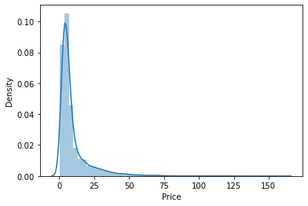

```python
sns.distplot(data["Price"])
```

This is a highly skewed distribution. Try log transformation on this column to see of that helps normalize the distribution.

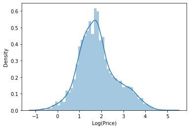

```python
sns.distplot(np.log(data["Price"]), axlabel="Log(Price)")
```

Log Transformation has definitely helped in reducing the skew. Creating a new column with the transformed variable.

```python
data["price_log"] = np.log(data["Price"])
```

### Price/Location

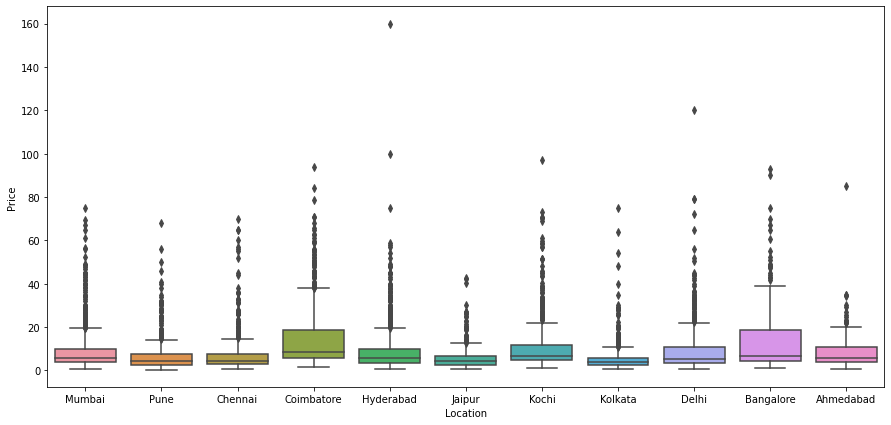

```python
plt.figure(figsize=(15, 7))
sns.boxplot(x="Location", y="Price", data=data)
```

Price has a large IQR in Coimbatore and Bangalore

### Kilometers_Driven

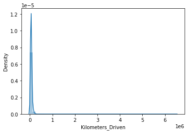

```python
sns.distplot(data["Kilometers_Driven"])
```

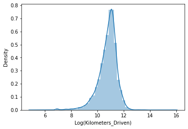

```python
sns.distplot(np.log(data["Kilometers_Driven"]), axlabel="Log(Kilometers_Driven)")
```

Log transformation has reduced the extreme skewness.

```python
data["kilometers_driven_log"] = np.log(data["Kilometers_Driven"])
```

### Bivariate Distributions

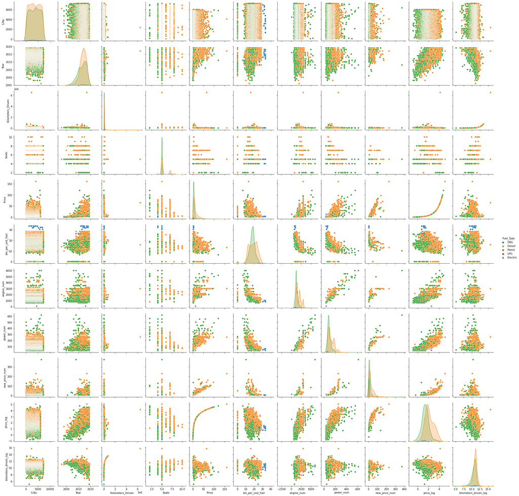

```python
sns.pairplot(data, hue="Fuel_Type")
```

- Kilometers Driven does not seem to have a relationship with price.
- Price has a positive relationship with Year. Newer the car, higher the price.
- S.No. No helpful insights.
- 2 seater cars are all luxury variants. Cars with 8-10 seats are exclusively mid to high range.
- Mileage does not seem to show much relationship with the price of used cars.
- Engine displacement and Power of the car have a positive relationship with the price.
- New Price and Used Car Price are also positively correlated, which is expected.
- Kilometers Driven has a relationship with the Year variable. Generally, newer the car the lesser the kilometers driven.
- CNG cars are outliers when it comes to Mileage. The mileage of these cars is very high.
- Mileage and power of newer cars is increasing due to advancement in technology.
- Mileage has a negative correlation with engine displacement and power. More powerful the engine, more fuel it consumes.

### Correlation between numeric Variables

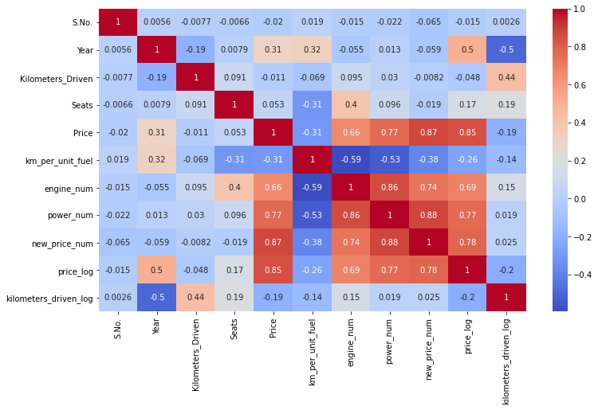

```python
plt.figure(figsize=(12, 7))
sns.heatmap(data.corr(), annot=True, cmap="coolwarm")
```

- Power and engine are important predictors of price
- Need to impute missing values for new price.

## Missing Value Treatment

```python
data.isnull().sum()
```

```
S.No.                       0
Name                        0
Location                    0
Year                        0
Kilometers_Driven           0
Fuel_Type                   0
Transmission                0
Owner_Type                  0
Seats                      53
Price                    1234
km_per_unit_fuel            2
engine_num                 46
power_num                 175
new_price_num            6247
Brand                       0
Model                       0
price_log                1234
kilometers_driven_log       0
dtype: int64
```

### Seats

```python
data[data["Seats"].isnull()]
```

|  | S.No. | Name | Location | Year | Kilometers_Driven | Fuel_Type | Transmission | Owner_Type | Seats | Price | km_per_unit_fuel | engine_num | power_num | new_price_num | Brand | Model | price_log | kilometers_driven_log |
| --- | --- | --- | --- | --- | --- | --- | --- | --- | --- | --- | --- | --- | --- | --- | --- | --- | --- | --- |
| 194 | 194 | Honda City 1.5 GXI | Ahmedabad | 2007 | 60006 | Petrol | Manual | First | NaN | 2.95 | 0.00 | NaN | NaN | NaN | honda | city | 1.081805 | 11.002200 |
| 208 | 208 | Maruti Swift 1.3 VXi | Kolkata | 2010 | 42001 | Petrol | Manual | First | NaN | 2.11 | 16.10 | NaN | NaN | NaN | maruti | swift | 0.746688 | 10.645449 |
| 229 | 229 | Ford Figo Diesel | Bangalore | 2015 | 70436 | Diesel | Manual | First | NaN | 3.60 | 0.00 | 1498.0 | 99.0 | NaN | ford | figo | 1.280934 | 11.162460 |
| 733 | 733 | Maruti Swift 1.3 VXi | Chennai | 2006 | 97800 | Petrol | Manual | Third | NaN | 1.75 | 16.10 | NaN | NaN | NaN | maruti | swift | 0.559616 | 11.490680 |
| 749 | 749 | Land Rover Range Rover 3.0 D | Mumbai | 2008 | 55001 | Diesel | Automatic | Second | NaN | 26.50 | 0.00 | NaN | NaN | NaN | land | rover | 3.277145 | 10.915107 |
| 1294 | 1294 | Honda City 1.3 DX | Delhi | 2009 | 55005 | Petrol | Manual | First | NaN | 3.20 | 12.80 | NaN | NaN | NaN | honda | city | 1.163151 | 10.915179 |
| 1327 | 1327 | Maruti Swift 1.3 ZXI | Hyderabad | 2015 | 50295 | Petrol | Manual | First | NaN | 5.80 | 16.10 | NaN | NaN | NaN | maruti | swift | 1.757858 | 10.825661 |
| 1385 | 1385 | Honda City 1.5 GXI | Pune | 2004 | 115000 | Petrol | Manual | Second | NaN | 1.50 | 0.00 | NaN | NaN | NaN | honda | city | 0.405465 | 11.652687 |
| 1460 | 1460 | Land Rover Range Rover Sport 2005 2012 Sport | Coimbatore | 2008 | 69078 | Petrol | Manual | First | NaN | 40.88 | 0.00 | NaN | NaN | NaN | land | rover | 3.710641 | 11.142992 |
| 1917 | 1917 | Honda City 1.5 EXI | Jaipur | 2005 | 88000 | Petrol | Manual | Second | NaN | 1.70 | 13.00 | 1493.0 | 100.0 | NaN | honda | city | 0.530628 | 11.385092 |
| 2074 | 2074 | Maruti Swift 1.3 LXI | Pune | 2011 | 24255 | Petrol | Manual | First | NaN | 3.15 | 16.10 | NaN | NaN | NaN | maruti | swift | 1.147402 | 10.096378 |
| 2096 | 2096 | Hyundai Santro LP zipPlus | Coimbatore | 2004 | 52146 | Petrol | Manual | First | NaN | 1.93 | 0.00 | NaN | NaN | NaN | hyundai | santro | 0.657520 | 10.861803 |
| 2264 | 2264 | Toyota Etios Liva V | Pune | 2012 | 24500 | Petrol | Manual | Second | NaN | 2.95 | 18.30 | NaN | NaN | NaN | toyota | etios | 1.081805 | 10.106428 |
| 2325 | 2325 | Maruti Swift 1.3 VXI ABS | Pune | 2015 | 67000 | Petrol | Manual | First | NaN | 4.70 | 16.10 | NaN | NaN | NaN | maruti | swift | 1.547563 | 11.112448 |
| 2335 | 2335 | Maruti Swift 1.3 VXi | Mumbai | 2007 | 55000 | Petrol | Manual | Second | NaN | 1.75 | 16.10 | NaN | NaN | NaN | maruti | swift | 0.559616 | 10.915088 |
| 2369 | 2369 | Maruti Estilo LXI | Chennai | 2008 | 56000 | Petrol | Manual | Second | NaN | 1.50 | 19.50 | 1061.0 | NaN | NaN | maruti | estilo | 0.405465 | 10.933107 |
| 2530 | 2530 | BMW 5 Series 520d Sedan | Kochi | 2014 | 64158 | Diesel | Automatic | First | NaN | 17.89 | 18.48 | NaN | NaN | NaN | bmw | 5 | 2.884242 | 11.069104 |
| 2542 | 2542 | Hyundai Santro GLS II - Euro II | Bangalore | 2011 | 65000 | Petrol | Manual | Second | NaN | 3.15 | 0.00 | NaN | NaN | NaN | hyundai | santro | 1.147402 | 11.082143 |
| 2623 | 2623 | BMW 5 Series 520d Sedan | Pune | 2012 | 95000 | Diesel | Automatic | Second | NaN | 18.00 | 18.48 | NaN | NaN | NaN | bmw | 5 | 2.890372 | 11.461632 |
| 2668 | 2668 | Maruti Swift 1.3 VXi | Kolkata | 2014 | 32986 | Petrol | Manual | First | NaN | 4.24 | 16.10 | NaN | NaN | NaN | maruti | swift | 1.444563 | 10.403839 |
| 2737 | 2737 | Maruti Wagon R Vx | Jaipur | 2001 | 200000 | Petrol | Manual | First | NaN | 0.70 | 12.00 | NaN | NaN | NaN | maruti | wagon | -0.356675 | 12.206073 |
| 2780 | 2780 | Hyundai Santro GLS II - Euro II | Pune | 2009 | 100000 | Petrol | Manual | First | NaN | 1.60 | 0.00 | NaN | NaN | NaN | hyundai | santro | 0.470004 | 11.512925 |
| 2842 | 2842 | Hyundai Santro GLS II - Euro II | Bangalore | 2012 | 43000 | Petrol | Manual | First | NaN | 3.25 | 0.00 | NaN | NaN | NaN | hyundai | santro | 1.178655 | 10.668955 |
| 3272 | 3272 | BMW 5 Series 520d Sedan | Mumbai | 2008 | 81000 | Diesel | Automatic | Second | NaN | 10.50 | 18.48 | NaN | NaN | NaN | bmw | 5 | 2.351375 | 11.302204 |
| 3404 | 3404 | Maruti Swift 1.3 VXi | Jaipur | 2006 | 125000 | Petrol | Manual | Fourth & Above | NaN | 2.35 | 16.10 | NaN | NaN | NaN | maruti | swift | 0.854415 | 11.736069 |
| 3520 | 3520 | BMW 5 Series 520d Sedan | Delhi | 2012 | 90000 | Diesel | Automatic | First | NaN | 14.50 | 18.48 | NaN | NaN | NaN | bmw | 5 | 2.674149 | 11.407565 |
| 3522 | 3522 | Hyundai Santro GLS II - Euro II | Kochi | 2012 | 66400 | Petrol | Manual | First | NaN | 2.66 | 0.00 | NaN | NaN | NaN | hyundai | santro | 0.978326 | 11.103452 |
| 3800 | 3800 | Ford Endeavour Hurricane LE | Mumbai | 2012 | 129000 | Diesel | Automatic | First | NaN | 7.00 | 12.80 | 2953.0 | NaN | NaN | ford | endeavour | 1.945910 | 11.767568 |
| 3810 | 3810 | Honda CR-V AT With Sun Roof | Kolkata | 2013 | 27000 | Petrol | Automatic | First | NaN | 11.99 | 14.00 | NaN | NaN | NaN | honda | cr-v | 2.484073 | 10.203592 |
| 3882 | 3882 | Maruti Estilo LXI | Kolkata | 2010 | 40000 | Petrol | Manual | Second | NaN | 2.50 | 19.50 | 1061.0 | NaN | NaN | maruti | estilo | 0.916291 | 10.596635 |
| 4011 | 4011 | Fiat Punto 1.3 Emotion | Pune | 2011 | 45271 | Diesel | Manual | First | NaN | 2.60 | 20.30 | NaN | NaN | NaN | fiat | punto | 0.955511 | 10.720422 |
| 4152 | 4152 | Land Rover Range Rover 3.0 D | Mumbai | 2003 | 75000 | Diesel | Automatic | Second | NaN | 16.11 | 0.00 | NaN | NaN | NaN | land | rover | 2.779440 | 11.225243 |
| 4229 | 4229 | Hyundai Santro Xing XG | Bangalore | 2005 | 79000 | Petrol | Manual | Second | NaN | 1.65 | 17.00 | NaN | NaN | NaN | hyundai | santro | 0.500775 | 11.277203 |
| 4577 | 4577 | BMW 5 Series 520d Sedan | Delhi | 2012 | 72000 | Diesel | Automatic | Third | NaN | 13.85 | 18.48 | NaN | NaN | NaN | bmw | 5 | 2.628285 | 11.184421 |
| 4604 | 4604 | Honda Jazz Select Edition | Pune | 2011 | 98000 | Petrol | Manual | First | NaN | 3.15 | 16.70 | NaN | NaN | NaN | honda | jazz | 1.147402 | 11.492723 |
| 4697 | 4697 | Fiat Punto 1.2 Dynamic | Kochi | 2017 | 17941 | Petrol | Manual | First | NaN | 3.93 | 15.70 | NaN | NaN | NaN | fiat | punto | 1.368639 | 9.794844 |
| 4712 | 4712 | Hyundai Santro Xing XG | Pune | 2003 | 80000 | Petrol | Manual | Second | NaN | 0.90 | 17.00 | NaN | NaN | NaN | hyundai | santro | -0.105361 | 11.289782 |
| 4952 | 4952 | Fiat Punto 1.4 Emotion | Kolkata | 2010 | 47000 | Petrol | Manual | First | NaN | 1.49 | 14.60 | NaN | NaN | NaN | fiat | punto | 0.398776 | 10.757903 |
| 5015 | 5015 | Maruti Swift 1.3 VXi | Delhi | 2006 | 63000 | Petrol | Manual | First | NaN | 1.60 | 16.10 | NaN | NaN | NaN | maruti | swift | 0.470004 | 11.050890 |
| 5185 | 5185 | Maruti Swift 1.3 LXI | Delhi | 2012 | 52000 | Petrol | Manual | First | NaN | 3.65 | 16.10 | NaN | NaN | NaN | maruti | swift | 1.294727 | 10.858999 |
| 5270 | 5270 | Honda City 1.5 GXI | Bangalore | 2002 | 53000 | Petrol | Manual | Second | NaN | 1.85 | 0.00 | NaN | NaN | NaN | honda | city | 0.615186 | 10.878047 |
| 5893 | 5893 | Maruti Estilo LXI | Chennai | 2008 | 51000 | Petrol | Manual | Second | NaN | 1.75 | 19.50 | 1061.0 | NaN | NaN | maruti | estilo | 0.559616 | 10.839581 |
| 6042 | 6042 | Skoda Laura 1.8 TSI Ambition | Bangalore | 2009 | 72000 | Petrol | Manual | Second | NaN | NaN | 17.50 | NaN | NaN | NaN | skoda | laura | NaN | 11.184421 |
| 6541 | 6541 | Toyota Etios Liva Diesel TRD Sportivo | Bangalore | 2012 | 56600 | Diesel | Manual | First | NaN | NaN | 23.59 | NaN | NaN | NaN | toyota | etios | NaN | 10.943764 |
| 6544 | 6544 | Hyundai i20 new Sportz AT 1.4 | Bangalore | 2012 | 58000 | Petrol | Automatic | Second | NaN | NaN | 15.00 | NaN | NaN | NaN | hyundai | i20 | NaN | 10.968198 |
| 6633 | 6633 | Mahindra TUV 300 P4 | Kolkata | 2016 | 27000 | Diesel | Manual | First | NaN | NaN | 0.00 | NaN | NaN | NaN | mahindra | tuv | NaN | 10.203592 |
| 6643 | 6643 | BMW 5 Series 520d Sedan | Bangalore | 2009 | 150000 | Diesel | Automatic | Second | NaN | NaN | 18.48 | NaN | NaN | NaN | bmw | 5 | NaN | 11.918391 |
| 6651 | 6651 | Maruti Swift 1.3 VXi | Kolkata | 2015 | 36009 | Petrol | Manual | First | NaN | NaN | 16.10 | NaN | NaN | NaN | maruti | swift | NaN | 10.491524 |
| 6677 | 6677 | Fiat Punto 1.4 Emotion | Jaipur | 2010 | 65000 | Petrol | Manual | Third | NaN | NaN | 14.60 | NaN | NaN | NaN | fiat | punto | NaN | 11.082143 |
| 6685 | 6685 | Maruti Swift 1.3 VXi | Pune | 2010 | 115000 | Petrol | Manual | Second | NaN | NaN | 16.10 | NaN | NaN | NaN | maruti | swift | NaN | 11.652687 |
| 6880 | 6880 | BMW 5 Series 520d Sedan | Chennai | 2009 | 95000 | Diesel | Automatic | Second | NaN | NaN | 18.48 | NaN | NaN | NaN | bmw | 5 | NaN | 11.461632 |
| 6902 | 6902 | Toyota Etios Liva V | Kochi | 2012 | 59311 | Petrol | Manual | First | NaN | NaN | 18.30 | NaN | NaN | NaN | toyota | etios | NaN | 10.990550 |
| 6957 | 6957 | Honda Jazz 2020 Petrol | Kochi | 2019 | 11574 | Petrol | Manual | First | NaN | NaN | 0.00 | 1199.0 | 88.7 | NaN | honda | jazz | NaN | 9.356516 |

```python
data.groupby(["Brand", "Model"], as_index=False)["Seats"].median()
```

|  | Brand | Model | Seats |
| --- | --- | --- | --- |
| 0 | ambassador | classic | 5.0 |
| 1 | audi | a3 | 5.0 |
| 2 | audi | a4 | 5.0 |
| 3 | audi | a6 | 5.0 |
| 4 | audi | a7 | 5.0 |
| ... | ... | ... | ... |
| 217 | volvo | s60 | 5.0 |
| 218 | volvo | s80 | 5.0 |
| 219 | volvo | v40 | 5.0 |
| 220 | volvo | xc60 | 5.0 |
| 221 | volvo | xc90 | 7.0 |

222 rows × 3 columns

```python
data["Seats"] = data.groupby(["Brand", "Model"])["Seats"].transform(
    lambda x: x.fillna(x.median())
)
```

```python
data[data["Seats"].isnull()]
```

|  | S.No. | Name | Location | Year | Kilometers_Driven | Fuel_Type | Transmission | Owner_Type | Seats | Price | km_per_unit_fuel | engine_num | power_num | new_price_num | Brand | Model | price_log | kilometers_driven_log |
| --- | --- | --- | --- | --- | --- | --- | --- | --- | --- | --- | --- | --- | --- | --- | --- | --- | --- | --- |
| 2369 | 2369 | Maruti Estilo LXI | Chennai | 2008 | 56000 | Petrol | Manual | Second | NaN | 1.50 | 19.5 | 1061.0 | NaN | NaN | maruti | estilo | 0.405465 | 10.933107 |
| 3882 | 3882 | Maruti Estilo LXI | Kolkata | 2010 | 40000 | Petrol | Manual | Second | NaN | 2.50 | 19.5 | 1061.0 | NaN | NaN | maruti | estilo | 0.916291 | 10.596635 |
| 5893 | 5893 | Maruti Estilo LXI | Chennai | 2008 | 51000 | Petrol | Manual | Second | NaN | 1.75 | 19.5 | 1061.0 | NaN | NaN | maruti | estilo | 0.559616 | 10.839581 |

```python
data["Seats"] = data["Seats"].fillna(5.0)
```

```python
data["engine_num"] = data.groupby(["Brand", "Model"])["engine_num"].transform(
    lambda x: x.fillna(x.median())
)
data["power_num"] = data.groupby(["Brand", "Model"])["power_num"].transform(
    lambda x: x.fillna(x.median())
)
data["new_price_num"] = data.groupby(["Brand", "Model"])["new_price_num"].transform(
    lambda x: x.fillna(x.median())
)
```

```python
data.isnull().sum()
```

```
S.No.                       0
Name                        0
Location                    0
Year                        0
Kilometers_Driven           0
Fuel_Type                   0
Transmission                0
Owner_Type                  0
Seats                       0
Price                    1234
km_per_unit_fuel            2
engine_num                  0
power_num                  12
new_price_num            1512
Brand                       0
Model                       0
price_log                1234
kilometers_driven_log       0
dtype: int64
```

- There are still some NAs in power and new_price_num.
- There are a few car brands and models in our dataset that do not contain the new price information at all.
- Must estimate the new price using the other features.
- KNN imputation will be used.
- This sklearn method requires us to encode categorical variables if we are using them for imputation.
- In this particular case using only select numeric features for imputation.

```python
from sklearn.impute import KNNImputer

imputer = KNNImputer(n_neighbors=3, weights="uniform")
temp_df_for_imputation = data[
    ["engine_num", "power_num", "Year", "km_per_unit_fuel", "new_price_num", "Seats"]
]
temp_df_for_imputation = imputer.fit_transform(temp_df_for_imputation)
temp_df_for_imputation = pd.DataFrame(
    temp_df_for_imputation,
    columns=[
        "engine_num",
        "power_num",
        "Year",
        "km_per_unit_fuel",
        "new_price_num",
        "Seats",
    ],
)

data["new_price_num"] = temp_df_for_imputation["new_price_num"]
data["power_num"] = temp_df_for_imputation["power_num"]
data["km_per_unit_fuel"] = temp_df_for_imputation["km_per_unit_fuel"]
```

```python
data.isnull().sum()
```

```
S.No.                       0
Name                        0
Location                    0
Year                        0
Kilometers_Driven           0
Fuel_Type                   0
Transmission                0
Owner_Type                  0
Seats                       0
Price                    1234
km_per_unit_fuel            0
engine_num                  0
power_num                   0
new_price_num               0
Brand                       0
Model                       0
price_log                1234
kilometers_driven_log       0
dtype: int64
```

```python
data.drop(columns=["Kilometers_Driven", "Name", "S.No."], inplace=True)

# Drop the rows where 'Price' == NaN and proceed to modelling
data = data[data["Price"].notna()]
```

Define dependent variable

```python
ind_vars = data.drop(["Price", "price_log"], axis=1)
dep_var = data[["price_log", "Price"]]
```

Creating dummy variables

```python
def encode_cat_vars(x):
    x = pd.get_dummies(
        x,
        columns=x.select_dtypes(include=["object", "category"]).columns.tolist(),
        drop_first=True,
    )
    return x


ind_vars_num = encode_cat_vars(ind_vars)
ind_vars_num.head()
```

|  | Year | Seats | km_per_unit_fuel | engine_num | power_num | new_price_num | kilometers_driven_log | Location_Bangalore | Location_Chennai | Location_Coimbatore | Location_Delhi | Location_Hyderabad | Location_Jaipur | Location_Kochi | Location_Kolkata | Location_Mumbai | Location_Pune | Fuel_Type_Diesel | Fuel_Type_Electric | Fuel_Type_LPG | Fuel_Type_Petrol | Transmission_Manual | Owner_Type_Fourth & Above | Owner_Type_Second | Owner_Type_Third | Brand_audi | Brand_bentley | Brand_bmw | Brand_chevrolet | … |
| --- | --- | --- | --- | --- | --- | --- | --- | --- | --- | --- | --- | --- | --- | --- | --- | --- | --- | --- | --- | --- | --- | --- | --- | --- | --- | --- | --- | --- | --- | --- |
| 0 | 2010 | 5.0 | 26.60 | 998.0 | 58.16 | 5.51 | 11.184421 | 0 | 0 | 0 | 0 | 0 | 0 | 0 | 0 | 1 | 0 | 0 | 0 | 0 | 0 | 1 | 0 | 0 | 0 | 0 | 0 | 0 | 0 | … |
| 1 | 2015 | 5.0 | 19.67 | 1582.0 | 126.20 | 16.06 | 10.621327 | 0 | 0 | 0 | 0 | 0 | 0 | 0 | 0 | 0 | 1 | 1 | 0 | 0 | 0 | 1 | 0 | 0 | 0 | 0 | 0 | 0 | 0 | … |
| 2 | 2011 | 5.0 | 18.20 | 1199.0 | 88.70 | 8.61 | 10.736397 | 0 | 1 | 0 | 0 | 0 | 0 | 0 | 0 | 0 | 0 | 0 | 0 | 0 | 1 | 1 | 0 | 0 | 0 | 0 | 0 | 0 | 0 | … |
| 3 | 2012 | 7.0 | 20.77 | 1248.0 | 88.76 | 11.27 | 11.373663 | 0 | 1 | 0 | 0 | 0 | 0 | 0 | 0 | 0 | 0 | 1 | 0 | 0 | 0 | 1 | 0 | 0 | 0 | 0 | 0 | 0 | 0 | … |
| 4 | 2013 | 5.0 | 15.20 | 1968.0 | 140.80 | 53.14 | 10.613246 | 0 | 0 | 1 | 0 | 0 | 0 | 0 | 0 | 0 | 0 | 1 | 0 | 0 | 0 | 0 | 0 | 1 | 0 | 1 | 0 | 0 | 0 | … |

Split the data into train and test

```python
from sklearn.model_selection import train_test_split

x_train, x_test, y_train, y_test = train_test_split(
    ind_vars_num, dep_var, test_size=0.3, random_state=1
)
```

```python
print("Number of rows in train data =", x_train.shape[0])
print("Number of rows in train data =", x_test.shape[0])
```

```
Number of rows in train data = 4213
Number of rows in train data = 1806
```

Fitting a linear model

```python
import statsmodels.api as sm

x_train = sm.add_constant(x_train)

x_test = sm.add_constant(x_test)


def build_ols_model(train):

    olsmodel = sm.OLS(y_train["price_log"], train)
    return olsmodel.fit()


olsmodel1 = build_ols_model(x_train)
print(olsmodel1.summary())
```

```
                            OLS Regression Results
==============================================================================
Dep. Variable:              price_log   R-squared:                       0.959
Model:                            OLS   Adj. R-squared:                  0.957
Method:                 Least Squares   F-statistic:                     407.4
Date:                Sat, 03 Jul 2021   Prob (F-statistic):               0.00
Time:                        12:31:20   Log-Likelihood:                 1347.6
No. Observations:                4213   AIC:                            -2231.
Df Residuals:                    3981   BIC:                            -758.9
Df Model:                         231
Covariance Type:            nonrobust
=============================================================================================
                                coef    std err          t      P>|t|      [0.025      0.975]
---------------------------------------------------------------------------------------------
const                      -204.8609      2.878    -71.180      0.000    -210.504    -199.218
Year                          0.1064      0.001     72.730      0.000       0.103       0.109
Seats                         0.0004      0.014      0.029      0.977      -0.028       0.028
km_per_unit_fuel             -0.0006      0.001     -0.413      0.680      -0.003       0.002
engine_num                   -0.0001   2.25e-05     -5.986      0.000      -0.000   -9.05e-05
power_num                     0.0030      0.000     12.293      0.000       0.003       0.003
new_price_num                 0.0045      0.001      6.843      0.000       0.003       0.006
kilometers_driven_log        -0.0757      0.006    -13.717      0.000      -0.087      -0.065
Location_Bangalore            0.1758      0.019      9.324      0.000       0.139       0.213
Location_Chennai              0.0536      0.018      3.003      0.003       0.019       0.089
Location_Coimbatore           0.1462      0.017      8.483      0.000       0.112       0.180
Location_Delhi               -0.0802      0.017     -4.614      0.000      -0.114      -0.046
Location_Hyderabad            0.1548      0.017      9.275      0.000       0.122       0.188
Location_Jaipur              -0.0162      0.018     -0.891      0.373      -0.052       0.019
Location_Kochi               -0.0153      0.017     -0.887      0.375      -0.049       0.018
Location_Kolkata             -0.2193      0.018    -12.411      0.000      -0.254      -0.185
Location_Mumbai              -0.0583      0.017     -3.481      0.001      -0.091      -0.025
Location_Pune                -0.0189      0.017     -1.096      0.273      -0.053       0.015
Fuel_Type_Diesel              0.0657      0.032      2.023      0.043       0.002       0.129
Fuel_Type_Electric           -0.1397      0.087     -1.609      0.108      -0.310       0.031
Fuel_Type_LPG                -0.0371      0.081     -0.459      0.646      -0.195       0.121
Fuel_Type_Petrol             -0.0535      0.033     -1.599      0.110      -0.119       0.012
Transmission_Manual          -0.1148      0.010    -11.141      0.000      -0.135      -0.095
Owner_Type_Fourth & Above    -0.1289      0.080     -1.620      0.105      -0.285       0.027
Owner_Type_Second            -0.0561      0.008     -6.677      0.000      -0.073      -0.040
Owner_Type_Third             -0.1662      0.023     -7.372      0.000      -0.210      -0.122
```

[output cut: 235 more lines]

```
Model_yeti                   -0.6872      0.068    -10.164      0.000      -0.820      -0.555
Model_z4                      0.3276      0.225      1.458      0.145      -0.113       0.768
Model_zen                    -0.8472      0.074    -11.486      0.000      -0.992      -0.703
Model_zest                   -0.5573      0.112     -4.969      0.000      -0.777      -0.337
==============================================================================
Omnibus:                     1909.848   Durbin-Watson:                   1.996
Prob(Omnibus):                  0.000   Jarque-Bera (JB):           104947.870
Skew:                          -1.376   Prob(JB):                         0.00
Kurtosis:                      27.296   Cond. No.                     8.26e+19
==============================================================================

Notes:
[1] Standard Errors assume that the covariance matrix of the errors is correctly specified.
[2] The smallest eigenvalue is 4.23e-30. This might indicate that there are
strong multicollinearity problems or that the design matrix is singular.
```

- Both the R-squared and Adjusted R squared of our model are very high. Indicating we have been able to create a very good model that is able to explain variance in price of used cars for up to 95%.
- The model is not an underfitted model.
- To be able to make statistical inferences from the model, testing that the linear regression assumptions are followed is necessary.
- Before moving on to assumption testing, a performance check on the test data will be completed.

```python
import math


def rmse(predictions, targets):
    return np.sqrt(((targets - predictions) ** 2).mean())



def mape(predictions, targets):
    return np.mean(np.abs((targets - predictions)) / targets) * 100



def mae(predictions, targets):
    return np.mean(np.abs((targets - predictions)))



def model_pref(olsmodel, x_train, x_test):


    y_pred_train_pricelog = olsmodel.predict(x_train)
    y_pred_train_Price = y_pred_train_pricelog.apply(math.exp)
    y_train_Price = y_train["Price"]


    y_pred_test_pricelog = olsmodel.predict(x_test)
    y_pred_test_Price = y_pred_test_pricelog.apply(math.exp)
    y_test_Price = y_test["Price"]

    print(
        pd.DataFrame(
            {
                "Data": ["Train", "Test"],
                "RMSE": [
                    rmse(y_pred_train_Price, y_train_Price),
                    rmse(y_pred_test_Price, y_test_Price),
                ],
                "MAE": [
                    mae(y_pred_train_Price, y_train_Price),
                    mae(y_pred_test_Price, y_test_Price),
                ],
                "MAPE": [
                    mape(y_pred_train_Price, y_train_Price),
                    mape(y_pred_test_Price, y_test_Price),
                ],
            }
        )
    )



model_pref(olsmodel1, x_train, x_test)
```

```
    Data       RMSE       MAE       MAPE
0  Train   2.871334  1.205577  12.964208
1   Test  11.163467  1.900189  14.935578
```

- Root Mean Squared Error of train and test data is very different, indicating that our model is overfitting the train data.
- Mean Absolute Error indicates that our current model is able to predict used cars prices within mean error of 1.9 lakhs on test data.
- The units of both RMSE and MAE are same - Lakhs in this case. But RMSE is greater than MAE because it penalizes the outliers more.
- Mean Absolute Percentage Error is ~15% on the test data.

## Checking the Linear Regression Assumptions

1. No Multicollinearity
2. Mean of residuals should be 0
3. No Heteroscedasticity
4. Linearity of variables
5. Normality of error terms

### Checking Assumption 1: No Multicollinearity

We will use VIF, to check if there is multicollinearity in the data.

Features having a VIF score >5 will be dropped/treated till all the features have a VIF score <5

```python
from statsmodels.stats.outliers_influence import variance_inflation_factor


def checking_vif(train):
    vif = pd.DataFrame()
    vif["feature"] = train.columns

    # calculating VIF for each feature
    vif["VIF"] = [
        variance_inflation_factor(train.values, i) for i in range(len(train.columns))
    ]
    return vif
```

```python
data.groupby(["Brand", "Model"])["new_price_num"].mean().sort_values(ascending=False)
```

```
Brand          Model
mercedes-benz  sl-class       198.306667
bentley        continental    198.306667
mercedes-benz  s-class        171.000000
bmw            7              157.230769
               6              137.886190
                                 ...
smart          fortwo           4.360000
maruti         800              4.360000
hyundai        eon              4.237760
datsun         redi             4.153333
               redi-go          4.153333
Name: new_price_num, Length: 215, dtype: float64
```

```python
df1 = data.copy()
df1["car_category"] = pd.cut(
    x=data["new_price_num"],
    bins=[0, 15, 30, 50, 200],
    labels=["Budget_Friendly", "Mid-Range", "Luxury_Cars", "Ultra_luxury"],
)
# car_category.value_counts()

# Drop the Brand and Model columns.
df1.drop(columns=["Brand", "Model"], axis=1, inplace=True)
```

Created a new variable - Car Category

```python
ind_vars = df1.drop(["Price", "price_log"], axis=1)
dep_var = df1[["price_log", "Price"]]


ind_vars_num = encode_cat_vars(ind_vars)


x_train, x_test, y_train, y_test = train_test_split(
    ind_vars_num, dep_var, test_size=0.3, random_state=1
)

print("Number of rows in train data =", x_train.shape[0])
print("Number of rows in train data =", x_test.shape[0], "\n\n")


x_train = sm.add_constant(x_train)

x_test = sm.add_constant(x_test)


olsmodel2 = build_ols_model(x_train)
print(olsmodel2.summary())
```

```
Number of rows in train data = 4213
Number of rows in train data = 1806


                            OLS Regression Results
==============================================================================
Dep. Variable:              price_log   R-squared:                       0.899
Model:                            OLS   Adj. R-squared:                  0.898
Method:                 Least Squares   F-statistic:                     1328.
Date:                Sat, 03 Jul 2021   Prob (F-statistic):               0.00
Time:                        12:40:03   Log-Likelihood:                -576.29
No. Observations:                4213   AIC:                             1211.
Df Residuals:                    4184   BIC:                             1395.
Df Model:                          28
Covariance Type:            nonrobust
=============================================================================================
                                coef    std err          t      P>|t|      [0.025      0.975]
---------------------------------------------------------------------------------------------
const                      -234.5764      3.841    -61.077      0.000    -242.106    -227.047
Year                          0.1173      0.002     61.941      0.000       0.114       0.121
Seats                         0.0335      0.007      4.627      0.000       0.019       0.048
km_per_unit_fuel             -0.0087      0.002     -5.592      0.000      -0.012      -0.006
engine_num                 2.878e-05   2.15e-05      1.337      0.181   -1.34e-05     7.1e-05
power_num                     0.0052      0.000     21.564      0.000       0.005       0.006
new_price_num                 0.0050      0.000     11.344      0.000       0.004       0.006
kilometers_driven_log        -0.0686      0.008     -8.766      0.000      -0.084      -0.053
Location_Bangalore            0.1748      0.028      6.149      0.000       0.119       0.230
Location_Chennai              0.0311      0.027      1.167      0.243      -0.021       0.083
Location_Coimbatore           0.1137      0.026      4.385      0.000       0.063       0.165
Location_Delhi               -0.0313      0.026     -1.192      0.233      -0.083       0.020
Location_Hyderabad            0.1364      0.025      5.430      0.000       0.087       0.186
Location_Jaipur              -0.0605      0.027     -2.211      0.027      -0.114      -0.007
Location_Kochi               -0.0168      0.026     -0.646      0.518      -0.068       0.034
Location_Kolkata             -0.2003      0.027     -7.531      0.000      -0.252      -0.148
Location_Mumbai              -0.0331      0.025     -1.315      0.189      -0.083       0.016
Location_Pune                -0.0363      0.026     -1.402      0.161      -0.087       0.014
Fuel_Type_Diesel              0.2294      0.045      5.055      0.000       0.140       0.318
Fuel_Type_Electric            1.0948      0.283      3.868      0.000       0.540       1.650
Fuel_Type_LPG                 0.0380      0.123      0.310      0.757      -0.203       0.279
Fuel_Type_Petrol             -0.0235      0.046     -0.507      0.612      -0.114       0.067
Transmission_Manual          -0.1605      0.014    -11.279      0.000      -0.188      -0.133
Owner_Type_Fourth & Above     0.0552      0.115      0.481      0.631      -0.170       0.280
Owner_Type_Second            -0.0747      0.013     -5.926      0.000      -0.099      -0.050
Owner_Type_Third             -0.1709      0.033     -5.200      0.000      -0.235      -0.106
car_category_Mid-Range        0.2325      0.016     14.585      0.000       0.201       0.264
car_category_Luxury_Cars      0.4123      0.022     18.823      0.000       0.369       0.455
car_category_Ultra_luxury     0.3657      0.034     10.856      0.000       0.300       0.432
==============================================================================
Omnibus:                     1539.255   Durbin-Watson:                   1.971
Prob(Omnibus):                  0.000   Jarque-Bera (JB):            23553.492
Skew:                          -1.321   Prob(JB):                         0.00
Kurtosis:                      14.278   Cond. No.                     2.34e+06
==============================================================================

Notes:
[1] Standard Errors assume that the covariance matrix of the errors is correctly specified.
[2] The condition number is large, 2.34e+06. This might indicate that there are
strong multicollinearity or other numerical problems.
```

The R squared and adjusted r squared values have decreased, but are still high indicating that we have been able to capture most of the information of the previous model even after reducing the number of predictor features.

As overfitting is decreased the r squared of train model should decrease.

```python
print(checking_vif(x_train))
```

```
                      feature            VIF
0                       const  801789.023788
1                        Year       2.106839
2                       Seats       1.819182
3            km_per_unit_fuel       2.778616
4                  engine_num       9.205081
5                   power_num       9.394281
6               new_price_num       7.607728
7       kilometers_driven_log       1.700098
8          Location_Bangalore       2.395730
9            Location_Chennai       2.963851
10        Location_Coimbatore       3.461106
11             Location_Delhi       3.090144
12         Location_Hyderabad       3.837060
13            Location_Jaipur       2.688775
14             Location_Kochi       3.464076
15           Location_Kolkata       3.042419
16            Location_Mumbai       3.920797
17              Location_Pune       3.307050
18           Fuel_Type_Diesel      27.829157
19         Fuel_Type_Electric       1.033358
20              Fuel_Type_LPG       1.164452
21           Fuel_Type_Petrol      28.930997
22        Transmission_Manual       2.230795
23  Owner_Type_Fourth & Above       1.019667
24          Owner_Type_Second       1.172296
25           Owner_Type_Third       1.107269
26     car_category_Mid-Range       1.511549
27   car_category_Luxury_Cars       2.497513
28  car_category_Ultra_luxury       6.696488
```

```python
model_pref(olsmodel2, x_train, x_test)
```

```
    Data      RMSE       MAE       MAPE
0  Train  4.800940  2.026240  22.846640
1   Test  3.873684  1.861864  20.259595
```

- The RMSE on train data has increased now, but has decreased on test data.
- The RMSE values on both the dataset being close to each other indicate that the model is not overfitting the training data anymore.
- Reducing overfitting has caused the MAE to increase on training data, but the test MAE has been reduced.
- MAPE on test data has increased to ~20%

### Removing Multicollinearity

1. Drop every column that has VIF score greater than 5.
2. Look at the adjusted R square of all these models.
3. Drop the variable that makes least change in Adjusted-R square.
4. Check the VIF Scores again.
5. Continue until all VIF scores under 5.

```python
def treating_multicollinearity(high_vif_columns, x_train, x_test):
    """
    Drop every column that has VIF score greater than 5, one by one.
    Look at the adjusted R square of all these models
    Look at the RMSE of all these models on test data
    """
    adj_rsq_scores = []
    rmse_test_data = []

    # build ols models by dropping one of these at a time and observe the Adjusted R-squared
    for cols in high_vif_columns:
        train = x_train.loc[:, ~x_train.columns.str.startswith(cols)]
        test = x_test.loc[:, ~x_test.columns.str.startswith(cols)]
        # Create the model
        olsres = build_ols_model(train)
        # Adj R-Sq
        adj_rsq_scores.append(olsres.rsquared_adj)
        # RMSE (Test data)
        y_pred_test_pricelog = olsres.predict(test)
        y_pred_test_Price = y_pred_test_pricelog.apply(math.exp)
        y_test_Price = y_test["Price"]
        rmse_test_data.append(rmse(y_pred_test_Price, y_test_Price))

    # Add new Adj_Rsq and RMSE after dropping each colmn
    temp = pd.DataFrame(
        {
            "col": high_vif_columns,
            "Adj_rsq_after_dropping_col": adj_rsq_scores,
            "Test RMSE": rmse_test_data,
        }
    ).sort_values(by="Adj_rsq_after_dropping_col", ascending=False)

    print(temp)
    print("\n\n")
```

```python
high_vif_columns = [
    "engine_num",
    "power_num",
    "new_price_num_log",
    "Fuel_Type",
    "car_category",
]
treating_multicollinearity(high_vif_columns, x_train, x_test)
```

```
                 col  Adj_rsq_after_dropping_col  Test RMSE
2  new_price_num_log                    0.898155   3.873684
0         engine_num                    0.898136   3.883795
3          Fuel_Type                    0.888137   3.992122
4       car_category                    0.888081   4.710526
1          power_num                    0.886863   3.763776
```

- Dropping cars_category would have the maximum impact on predictive power of the model.
- Drop engine_num and check the vif again

```python
col_to_drop = "engine_num"
x_train = x_train.loc[:, ~x_train.columns.str.startswith(col_to_drop)]
x_test = x_test.loc[:, ~x_test.columns.str.startswith(col_to_drop)]

# Check VIF now
vif = checking_vif(x_train)
print("VIF after dropping ", col_to_drop)
print(vif)
```

```
VIF after dropping  engine_num
                      feature            VIF
0                       const  798304.241227
1                        Year       2.098130
2                       Seats       1.500360
3            km_per_unit_fuel       2.479474
4                   power_num       4.784834
5               new_price_num       7.501351
6       kilometers_driven_log       1.699680
7          Location_Bangalore       2.395730
8            Location_Chennai       2.962683
9         Location_Coimbatore       3.460372
10             Location_Delhi       3.089417
11         Location_Hyderabad       3.834254
12            Location_Jaipur       2.688656
13             Location_Kochi       3.463678
14           Location_Kolkata       3.041034
15            Location_Mumbai       3.920787
16              Location_Pune       3.307044
17           Fuel_Type_Diesel      27.828098
18         Fuel_Type_Electric       1.032746
19              Fuel_Type_LPG       1.162897
20           Fuel_Type_Petrol      28.629848
21        Transmission_Manual       2.215580
22  Owner_Type_Fourth & Above       1.019339
23          Owner_Type_Second       1.172262
24           Owner_Type_Third       1.107258
25     car_category_Mid-Range       1.503683
26   car_category_Luxury_Cars       2.486882
27  car_category_Ultra_luxury       6.618689
```

- Dropping engine_num has brought the VIF of power_num below 5
- new_price_num, Fuel_Type and car_category still show some multicollinearity

```python
high_vif_columns = [
    "new_price_num",
    "Fuel_Type",
    "car_category",
]
treating_multicollinearity(high_vif_columns, x_train, x_test)
```

```
             col  Adj_rsq_after_dropping_col  Test RMSE
0  new_price_num                    0.894896   3.838391
2   car_category                    0.887761   4.708422
1      Fuel_Type                    0.886304   4.027055
```

```python
col_to_drop = "new_price_num"
x_train = x_train.loc[:, ~x_train.columns.str.startswith(col_to_drop)]
x_test = x_test.loc[:, ~x_test.columns.str.startswith(col_to_drop)]


vif = checking_vif(x_train)
print("VIF after dropping ", col_to_drop)
print(vif)
```

```
VIF after dropping  new_price_num
                      feature            VIF
0                       const  798205.283404
1                        Year       2.097917
2                       Seats       1.497615
3            km_per_unit_fuel       2.451716
4                   power_num       3.726292
5       kilometers_driven_log       1.698901
6          Location_Bangalore       2.394439
7            Location_Chennai       2.960656
8         Location_Coimbatore       3.457833
9              Location_Delhi       3.088178
10         Location_Hyderabad       3.831659
11            Location_Jaipur       2.687902
12             Location_Kochi       3.462889
13           Location_Kolkata       3.040563
14            Location_Mumbai       3.920003
15              Location_Pune       3.305599
16           Fuel_Type_Diesel      27.823686
17         Fuel_Type_Electric       1.032614
18              Fuel_Type_LPG       1.162703
19           Fuel_Type_Petrol      28.591055
20        Transmission_Manual       2.215532
21  Owner_Type_Fourth & Above       1.019290
22          Owner_Type_Second       1.171808
23           Owner_Type_Third       1.106724
24     car_category_Mid-Range       1.498034
25   car_category_Luxury_Cars       2.292216
26  car_category_Ultra_luxury       4.232480
```

```python
olsmodel3 = build_ols_model(x_train)
print(olsmodel3.summary())

print("\n\n")


model_pref(olsmodel3, x_train, x_test)
```

```
                            OLS Regression Results
==============================================================================
Dep. Variable:              price_log   R-squared:                       0.896
Model:                            OLS   Adj. R-squared:                  0.895
Method:                 Least Squares   F-statistic:                     1380.
Date:                Sat, 03 Jul 2021   Prob (F-statistic):               0.00
Time:                        12:48:39   Log-Likelihood:                -643.65
No. Observations:                4213   AIC:                             1341.
Df Residuals:                    4186   BIC:                             1513.
Df Model:                          26
Covariance Type:            nonrobust
=============================================================================================
                                coef    std err          t      P>|t|      [0.025      0.975]
---------------------------------------------------------------------------------------------
const                      -233.7436      3.893    -60.044      0.000    -241.376    -226.111
Year                          0.1170      0.002     60.903      0.000       0.113       0.121
Seats                         0.0343      0.007      5.139      0.000       0.021       0.047
km_per_unit_fuel             -0.0112      0.001     -7.533      0.000      -0.014      -0.008
power_num                     0.0064      0.000     41.246      0.000       0.006       0.007
kilometers_driven_log        -0.0703      0.008     -8.856      0.000      -0.086      -0.055
Location_Bangalore            0.1824      0.029      6.320      0.000       0.126       0.239
Location_Chennai              0.0399      0.027      1.474      0.141      -0.013       0.093
Location_Coimbatore           0.1224      0.026      4.647      0.000       0.071       0.174
Location_Delhi               -0.0246      0.027     -0.925      0.355      -0.077       0.028
Location_Hyderabad            0.1448      0.025      5.681      0.000       0.095       0.195
Location_Jaipur              -0.0549      0.028     -1.977      0.048      -0.109      -0.000
Location_Kochi               -0.0119      0.026     -0.450      0.653      -0.064       0.040
Location_Kolkata             -0.1957      0.027     -7.245      0.000      -0.249      -0.143
Location_Mumbai              -0.0289      0.026     -1.131      0.258      -0.079       0.021
Location_Pune                -0.0300      0.026     -1.140      0.254      -0.082       0.022
Fuel_Type_Diesel              0.2224      0.046      4.825      0.000       0.132       0.313
Fuel_Type_Electric            1.1411      0.287      3.970      0.000       0.578       1.705
Fuel_Type_LPG                 0.0136      0.125      0.110      0.913      -0.231       0.258
Fuel_Type_Petrol             -0.0495      0.047     -1.057      0.290      -0.141       0.042
Transmission_Manual          -0.1582      0.014    -10.979      0.000      -0.186      -0.130
Owner_Type_Fourth & Above     0.0487      0.117      0.418      0.676      -0.180       0.277
Owner_Type_Second            -0.0719      0.013     -5.617      0.000      -0.097      -0.047
Owner_Type_Third             -0.1794      0.033     -5.374      0.000      -0.245      -0.114
car_category_Mid-Range        0.2453      0.016     15.217      0.000       0.214       0.277
car_category_Luxury_Cars      0.4850      0.021     22.753      0.000       0.443       0.527
car_category_Ultra_luxury     0.5938      0.027     21.824      0.000       0.540       0.647
==============================================================================
Omnibus:                     1327.420   Durbin-Watson:                   1.960
Prob(Omnibus):                  0.000   Jarque-Bera (JB):            17469.076
Skew:                          -1.126   Prob(JB):                         0.00
Kurtosis:                      12.718   Cond. No.                     1.80e+06
==============================================================================

Notes:
[1] Standard Errors assume that the covariance matrix of the errors is correctly specified.
[2] The condition number is large, 1.8e+06. This might indicate that there are
strong multicollinearity or other numerical problems.



    Data      RMSE       MAE       MAPE
0  Train  5.046621  2.076723  22.988682
1   Test  3.838391  1.915291  20.639839
```

Model R-squared and Adjusted R squared is same as the previous model - olsmodel2. Removal of multicollinear variable has not caused any information loss in the model.

The RMSE of the model on train data has increased, but still small on the test data which is good.

Before making inferences from this model need to ensure that other model assumptions are followed.

### Checking Assumption 2: Mean of residuals should be 0

```python
residuals = olsmodel3.resid
np.mean(residuals)
```

```
-6.067673198812996e-14
```

### Checking Assumption 3: No Heteroscedasticity

- Homoscedacity - If the residuals are symmetrically distributed across the regression line, then the data is said to homoscedastic.
- Heteroscedasticity - If the residuals are not symmetrically distributed across the regression line, then the data is said to be heteroscedastic. In this case the residuals can form a funnel shape or any other non symmetrical shape.

Use `Goldfeldquandt Test` to test the following hypothesis

Null hypothesis : Residuals are homoscedastic Alternate hypothesis : Residuals have hetroscedasticity

alpha = 0.05

```python
import statsmodels.stats.api as sms
from statsmodels.compat import lzip

name = ["F statistic", "p-value"]
test = sms.het_goldfeldquandt(residuals, x_train)
lzip(name, test)
```

```
[('F statistic', 0.8889075306852735), ('p-value', 0.9963654482385906)]
```

Since p-value > 0.05 we cannot reject the Null Hypothesis that the residuals are homoscedastic.

Assumptions 3 is also satisfied by our olsmodel3.

### Checking Assumption 4: Linearity of variables

Predictor variables must have a linear relation with the dependent variable.

To test the assumption, plot residuals and fitted values on a plot and ensure that residuals do not form a strong pattern. They should be randomly and uniformly scattered on the x axis.

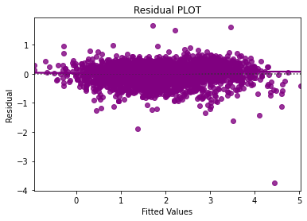

```python
fitted = olsmodel3.fittedvalues


sns.residplot(fitted, residuals, color="purple", lowess=True)
plt.xlabel("Fitted Values")
plt.ylabel("Residual")
plt.title("Residual PLOT")
plt.show()
```

Assumptions 4 is satisfied by our olsmodel3. There is no pattern in the residual vs fitted values plot.

### Checking Assumption 5: Normality of error terms

The residuals should be normally distributed.

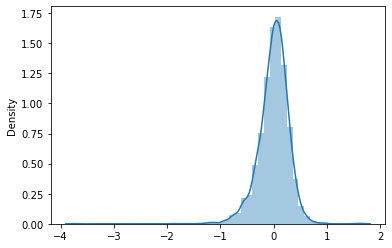

```python
sns.distplot(residuals)
```

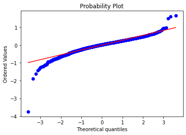

```python
import pylab
import scipy.stats as stats

stats.probplot(residuals, dist="norm", plot=pylab)
plt.show()
```

```python
print(olsmodel3.summary())
```

```
                            OLS Regression Results
==============================================================================
Dep. Variable:              price_log   R-squared:                       0.896
Model:                            OLS   Adj. R-squared:                  0.895
Method:                 Least Squares   F-statistic:                     1380.
Date:                Sat, 03 Jul 2021   Prob (F-statistic):               0.00
Time:                        12:54:51   Log-Likelihood:                -643.65
No. Observations:                4213   AIC:                             1341.
Df Residuals:                    4186   BIC:                             1513.
Df Model:                          26
Covariance Type:            nonrobust
=============================================================================================
                                coef    std err          t      P>|t|      [0.025      0.975]
---------------------------------------------------------------------------------------------
const                      -233.7436      3.893    -60.044      0.000    -241.376    -226.111
Year                          0.1170      0.002     60.903      0.000       0.113       0.121
Seats                         0.0343      0.007      5.139      0.000       0.021       0.047
km_per_unit_fuel             -0.0112      0.001     -7.533      0.000      -0.014      -0.008
power_num                     0.0064      0.000     41.246      0.000       0.006       0.007
kilometers_driven_log        -0.0703      0.008     -8.856      0.000      -0.086      -0.055
Location_Bangalore            0.1824      0.029      6.320      0.000       0.126       0.239
Location_Chennai              0.0399      0.027      1.474      0.141      -0.013       0.093
Location_Coimbatore           0.1224      0.026      4.647      0.000       0.071       0.174
Location_Delhi               -0.0246      0.027     -0.925      0.355      -0.077       0.028
Location_Hyderabad            0.1448      0.025      5.681      0.000       0.095       0.195
Location_Jaipur              -0.0549      0.028     -1.977      0.048      -0.109      -0.000
Location_Kochi               -0.0119      0.026     -0.450      0.653      -0.064       0.040
Location_Kolkata             -0.1957      0.027     -7.245      0.000      -0.249      -0.143
Location_Mumbai              -0.0289      0.026     -1.131      0.258      -0.079       0.021
Location_Pune                -0.0300      0.026     -1.140      0.254      -0.082       0.022
Fuel_Type_Diesel              0.2224      0.046      4.825      0.000       0.132       0.313
Fuel_Type_Electric            1.1411      0.287      3.970      0.000       0.578       1.705
Fuel_Type_LPG                 0.0136      0.125      0.110      0.913      -0.231       0.258
Fuel_Type_Petrol             -0.0495      0.047     -1.057      0.290      -0.141       0.042
Transmission_Manual          -0.1582      0.014    -10.979      0.000      -0.186      -0.130
Owner_Type_Fourth & Above     0.0487      0.117      0.418      0.676      -0.180       0.277
Owner_Type_Second            -0.0719      0.013     -5.617      0.000      -0.097      -0.047
Owner_Type_Third             -0.1794      0.033     -5.374      0.000      -0.245      -0.114
car_category_Mid-Range        0.2453      0.016     15.217      0.000       0.214       0.277
car_category_Luxury_Cars      0.4850      0.021     22.753      0.000       0.443       0.527
car_category_Ultra_luxury     0.5938      0.027     21.824      0.000       0.540       0.647
==============================================================================
Omnibus:                     1327.420   Durbin-Watson:                   1.960
Prob(Omnibus):                  0.000   Jarque-Bera (JB):            17469.076
Skew:                          -1.126   Prob(JB):                         0.00
Kurtosis:                      12.718   Cond. No.                     1.80e+06
==============================================================================

Notes:
[1] Standard Errors assume that the covariance matrix of the errors is correctly specified.
[2] The condition number is large, 1.8e+06. This might indicate that there are
strong multicollinearity or other numerical problems.
```

# Observations

# Business Insights and Recommendations

- Our final Linear Regression model has a MAPE of 20% on The test data, which means that we are able to predict within 20% of the price value. This is a very good model and we can use this model in production.
- Some southern markets tend to have higher prices. It might be a good strategy to plan growth in southern cities using this information. Markets like Kolkata(coeff = -0.2) are very risky and we need to be careful about investments in this area.
- Analysis on the cost side of things must be completed before discussion about profitability in the business.
- The next step post that would be to cluster different sets of data and see if we should make multiple models for different locations/car types.